# TRABAJO BIOLOGÍA DE SISTEMAS

#### Realizado por Fernando Lucas Ruiz

## Introducción

La gestión del mieloma múltiple, un cáncer de la sangre, es un desafío oncológico que requiere tratamientos específicos y mínimamente tóxicos. Este informe se centra en identificar blancos terapéuticos comparando tejidos sanos con células de mieloma. Se utilizaron modelos de tejidos de sangre, cerebro e hígado, y se contrastaron con líneas celulares de mieloma. Mediante análisis in silico, se identificaron genes cuya inhibición detiene el crecimiento en células de mieloma sin afectar tejidos sanos. El objetivo es desarrollar tratamientos que ataquen específicamente a las células cancerosas, preservando los tejidos normales. A continuación, se describen los métodos de esta investigación.

## Librerias

```python
import cplex
import cobra
import pickle
import pandas as pd
import matplotlib.pyplot as plt
from matplotlib_venn import venn3, venn3_circles, venn2
import mygene
import requests, sys
from bioservices import KEGG
from Bio import Entrez
from chembl_webresource_client.new_client import new_client
cobra.Configuration().solver = 'cplex'
```

## Modelos

Para el ejercicio de esta práctica he escogido los tejidos sanos de sangre, cerebro e hígado. En el caso de la sangre porque es el tejido que contiene un mayor número de células mieloides. En los otros dos, porque han sido mi area de conocimiento de estudio en mis investigaciones estos años.

En el caso de las lineas de mieloma multiple he escogido OCIMY7, L363 y KMS18.

```python
blood_model = cobra.io.read_sbml_model("../modelos/tejidos/blood.xml")
brain_model = cobra.io.read_sbml_model("../modelos/tejidos/brain.xml")
liver_model = cobra.io.read_sbml_model("../modelos/tejidos/liver.xml")
OCIMY7_MM_model = cobra.io.read_sbml_model("../modelos/MM/OCIMY7.xml")
L363_MM_model = cobra.io.read_sbml_model("../modelos/MM/L363.xml")
KMS18_MM_model = cobra.io.read_sbml_model("../modelos/MM/KMS18.xml")
human_model = cobra.io.load_matlab_model("../modelos/Human_1_17.mat")
```

```python
# Exportar modelos
with open("blood_model.pkl", "wb") as f:
    pickle.dump(blood_model, f)

with open("brain_model.pkl", "wb") as f:
    pickle.dump(brain_model, f)

with open("liver_model.pkl", "wb") as f:
    pickle.dump(liver_model, f)

with open("OCIMY7_MM_model.pkl", "wb") as f:
    pickle.dump(OCIMY7_MM_model, f)

with open("L363_MM_model.pkl", "wb") as f:
    pickle.dump(L363_MM_model, f)

with open("KMS18_MM_model.pkl", "wb") as f:
    pickle.dump(KMS18_MM_model, f)

with open("human_model.pkl", "wb") as f:
    pickle.dump(human_model, f)
```

```python
with open("blood_model.pkl", "rb") as f:
    blood_model = pickle.load(f)

# Cargar el modelo blood_model desde el archivo "blood_model.pkl"
with open("brain_model.pkl", "rb") as f:
    brain_model = pickle.load(f)

# Cargar el modelo blood_vessel_model desde el archivo "blood_vessel_model.pkl"
with open("liver_model.pkl", "rb") as f:
    liver_model = pickle.load(f)

# Cargar el modelo mieloma_INA6 desde el archivo "mieloma_INA6.pkl"
with open("OCIMY7_MM_model.pkl", "rb") as f:
    OCIMY7_MM_model = pickle.load(f)

# Cargar el modelo mieloma_JJN3 desde el archivo "mieloma_JJN3.pkl"
with open("L363_MM_model.pkl", "rb") as f:
    L363_MM_model = pickle.load(f)

# Cargar el modelo mieloma_KMM1 desde el archivo "mieloma_KMM1.pkl"
with open("KMS18_MM_model.pkl", "rb") as f:
    KMS18_MM_model = pickle.load(f)

# Cargar el modelo humano generico desde el archivo "human_model.pkl"
with open("human_model.pkl", "rb") as f:
    human_model = pickle.load(f)
```

### Genes esenciales

Iniciamos identificando los genes fundamentales para todos los modelos.

Los pasos a seguir son:

1. Creamos un diccionario vacío, denominado genes_blood, para recopilar información de los genes asociados a las reacciones en el modelo sanguíneo.
2. Recorremos cada reacción (r) en el modelo (blood_model).
3. grr representa la regla genética de la reacción asociada con r. Estas reglas definen qué genes están vinculados a la reacción y su impacto en la actividad de la misma.
4. El programa verifica cuántos genes (r.genes) están relacionados con esa reacción. Si no hay genes asociados (longitud cero), la reacción se registra en genes_blood con un conjunto de genes vacío.
5. Si solo un gen está asociado con la reacción, se añade al diccionario genes_blood, usando el ID de la reacción como clave.
6. Si la regla contiene "or" pero no "and", sugiere que múltiples genes están asociados con la reacción, pero su funcionamiento requiere solo uno de ellos. En este escenario, el conjunto de genes sigue vacío, indicando que no hay un único gen crítico para esa reacción.
7. Si la regla incluye "and" pero no "or", significa que todos los genes listados son necesarios para la reacción. El algoritmo divide grr por " and " y agrega los genes resultantes al diccionario.
8. Si la regla tiene tanto "and" como "or", representa una combinación de dependencias más complejas. Aquí, se registra un conjunto de todos los genes relacionados con la reacción en el diccionario.

Al finalizar, genes_blood contiene las reacciones como claves y conjuntos de IDs de genes esenciales como valores. Este proceso es vital para comprender qué genes son esenciales para las funciones metabólicas de la sangre en el modelo, lo que podría ser útil para identificar posibles blancos genéticos cuya inhibición podría afectar el crecimiento o supervivencia del tejido.

```python
# Genes esenciales para blood
genes_blood={}
for r in blood_model.reactions:
    grr=r.gene_reaction_rule
    if len(r.genes)==0:
        genes_blood[r.id]=set()
    if len(r.genes)==1:
        genes_blood[r.id]=set([g.id for g in r.genes])
    if "or" in grr and not "and" in grr:
        genes_blood[r.id]=set()
    if "and" in grr and not "or" in grr:
        genes_blood[r.id]= set(grr.split(" and "))
    if "and" in grr and "or" in grr:
        genes_blood[r.id]=set([g.id for g in r.genes])
```

```python
# Genes esenciales para brain
genes_brain={}
for r in brain_model.reactions:
    grr=r.gene_reaction_rule
    if len(r.genes)==0:
        genes_brain[r.id]=set()
    if len(r.genes)==1:
        genes_brain[r.id]=set([g.id for g in r.genes])
    if "or" in grr and not "and" in grr:
        genes_brain[r.id]=set()
    if "and" in grr and not "or" in grr:
        genes_brain[r.id]= set(grr.split(" and "))
    if "and" in grr and "or" in grr:
        genes_brain[r.id]=set([g.id for g in r.genes])
```

```python
# Genes esenciales para liver
genes_liver={}
for r in liver_model.reactions:
    grr=r.gene_reaction_rule
    if len(r.genes)==0:
        genes_liver[r.id]=set()
    if len(r.genes)==1:
        genes_liver[r.id]=set([g.id for g in r.genes])
    if "or" in grr and not "and" in grr:
        genes_liver[r.id]=set()
    if "and" in grr and not "or" in grr:
        genes_liver[r.id]= set(grr.split(" and "))
    if "and" in grr and "or" in grr:
        genes_liver[r.id]=set([g.id for g in r.genes])
```

```python
# Genes esenciales para OCIMY7_MM_model
genes_OCIMY7_MM={}
for r in OCIMY7_MM_model.reactions:
    grr=r.gene_reaction_rule
    if len(r.genes)==0:
        genes_OCIMY7_MM[r.id]=set()
    if len(r.genes)==1:
        genes_OCIMY7_MM[r.id]=set([g.id for g in r.genes])
    if "or" in grr and not "and" in grr:
        genes_OCIMY7_MM[r.id]=set()
    if "and" in grr and not "or" in grr:
        genes_OCIMY7_MM[r.id]= set(grr.split(" and "))
    if "and" in grr and "or" in grr:
        genes_OCIMY7_MM[r.id]=set([g.id for g in r.genes])
```

```python
# Genes esenciales para L363_MM_model
genes_L363_MM={}
for r in L363_MM_model.reactions:
    grr=r.gene_reaction_rule
    if len(r.genes)==0:
        genes_L363_MM[r.id]=set()
    if len(r.genes)==1:
        genes_L363_MM[r.id]=set([g.id for g in r.genes])
    if "or" in grr and not "and" in grr:
        genes_L363_MM[r.id]=set()
    if "and" in grr and not "or" in grr:
        genes_L363_MM[r.id]= set(grr.split(" and "))
    if "and" in grr and "or" in grr:
        genes_L363_MM[r.id]=set([g.id for g in r.genes])
```

```python
# Genes esenciales para KMS18_MM_model
genes_KMS18_MM={}
for r in KMS18_MM_model.reactions:
    grr=r.gene_reaction_rule
    if len(r.genes)==0:
        genes_KMS18_MM[r.id]=set()
    if len(r.genes)==1:
        genes_KMS18_MM[r.id]=set([g.id for g in r.genes])
    if "or" in grr and not "and" in grr:
        genes_KMS18_MM[r.id]=set()
    if "and" in grr and not "or" in grr:
        genes_KMS18_MM[r.id]= set(grr.split(" and "))
    if "and" in grr and "or" in grr:
        genes_KMS18_MM[r.id]=set([g.id for g in r.genes])
```

```python
# Genes esenciales para human_model
genes_human={}
for r in human_model.reactions:
    grr=r.gene_reaction_rule
    if len(r.genes)==0:
        genes_human[r.id]=set()
    if len(r.genes)==1:
        genes_human[r.id]=set([g.id for g in r.genes])
    if "or" in grr and not "and" in grr:
        genes_human[r.id]=set()
    if "and" in grr and not "or" in grr:
        genes_human[r.id]= set(grr.split(" and "))
    if "and" in grr and "or" in grr:
        genes_human[r.id]=set([g.id for g in r.genes])
```

```python
datos = {
    'blood': len(genes_blood),
    'brain': len(genes_brain),
    'liver': len(genes_liver),
    'OCIMY7': len(genes_OCIMY7_MM),
    'L363_MM': len(genes_L363_MM),
    'KMS18_MM': len(genes_KMS18_MM),
    'human': len(genes_human),
}
tabla = pd.DataFrame([datos], index=['Genes'])
tabla
```

|  | blood | brain | liver | OCIMY7 | L363_MM | KMS18_MM | human |
| --- | --- | --- | --- | --- | --- | --- | --- |
| Genes | 7697 | 8123 | 8340 | 7782 | 7842 | 7711 | 12969 |

## Optimizamos el modelo

En este paso, lo que vamos a realizar es calcular aquellos genes que permiten el crecimiento celular de cada uno de los modelos.

En primer lugar, vamos a tratar de encontrar la máxima cantidad de biomasa que se puede producir o maximizar en el contexto de los modelos que hemos elegido:

```python
maxBiomasa_blood = blood_model.slim_optimize()
maxBiomasa_brain = brain_model.slim_optimize()
maxBiomasa_liver = liver_model.slim_optimize()
maxBiomasa_OCIMY7_MM = OCIMY7_MM_model.slim_optimize()
maxBiomasa_L363_MM = L363_MM_model.slim_optimize()
maxBiomasa_KMS18_MM = KMS18_MM_model.slim_optimize()
maxBiomasa_human = human_model.slim_optimize()
```

```python
datos = {
    'blood': maxBiomasa_blood,
    'brain': maxBiomasa_brain,
    'liver': maxBiomasa_liver,
    'OCIMY7': maxBiomasa_OCIMY7_MM,
    'L363_MM': maxBiomasa_L363_MM,
    'KMS18_MM': maxBiomasa_KMS18_MM,
    'human' : maxBiomasa_human
}
tabla = pd.DataFrame([datos], index=['Biomasa'])
tabla
```

|  | blood | brain | liver | OCIMY7 | L363_MM | KMS18_MM | human |
| --- | --- | --- | --- | --- | --- | --- | --- |
| Biomasa | 81.562328 | 87.532599 | 78.603048 | 141.533119 | 116.417533 | 146.749531 | 124.760752 |

Como vemos la tasa de crecimiento de los tejidos sanos es muy parecida. En cambio la tasa de crecimiento de las 3 lineas de mieloma es mucho mayor.

```python
blood_model
```

| **Name** | M_Human__45__GEM |
| --- | --- |
| **Memory address** | 0x07face3397128 |
| **Number of metabolites** | 5426 |
| **Number of reactions** | 7697 |
| **Number of groups** | 134 |
| **Objective expression** | 1.0*MAR13082 - 1.0*MAR13082_reverse_11d67 |
| **Compartments** | Extracellular, Cytosol, Lysosome, Endoplasmic reticulum, Mitochondria, Peroxisome, Golgi apparatus, Nucleus, Inner mitochondria |

Para explicar el significado y la importancia de cada término en relación con el modelo, tomemos como referencia el modelo de sangre:

```python
biomasa_blood=blood_model.reactions.MAR13082
biomasa_brain=brain_model.reactions.MAR13082
biomasa_liver=liver_model.reactions.MAR13082
biomasa_OCIMY7=OCIMY7_MM_model.reactions.MAR13082
biomasa_L363 = L363_MM_model.reactions.MAR13082
biomasa_KMS18 =KMS18_MM_model.reactions.MAR13082
biomasa_human=human_model.reactions.MAR13082
```

```python
biomasa_blood
```

| **Reaction identifier** | MAR13082 |
| --- | --- |
| **Name** | Generic human cell biomass reaction |
| **Memory address** | 0x07face7154908 |
| **Stoichiometry** | 45.0 MAM01371c[c] + 0.0267 MAM01721n[n] + 45.0 MAM02040c[c] + 0.1124 MAM02847c[c] + 0.4062 MAM03161c[c] + 0.0012 MAM10012c[c] + 5.3375 MAM10013c[c] + 0.2212 MAM10014c[c] + 0.4835 MAM10015c[c] -->... 4… |
| **GPR** |  |
| **Lower bound** | 0.0 |
| **Upper bound** | 1000.0 |

- El identificador MAR13082 corresponde a la reacción de creación de biomasa en una célula humana según se modela en estudios metabólicos.
- El término biomasa hace referencia a la suma de todos los componentes macromoleculares que son esenciales para que una célula crezca y se divida.
- Normalmente, una "Regla de Reacción Genética" (GPR), que está ausente en este ejemplo, especificaría los genes involucrados en este proceso de síntesis de biomasa.
- Los parámetros denominados límite inferior y límite superior definen el intervalo de actividad para esta reacción dentro del modelo. Un límite inferior de 0.0 sugiere que la reacción no se produce en sentido inverso, y un límite superior de 1000.0 indica que puede ocurrir hacia adelante sin una restricción considerable, simbolizando que la capacidad de producción de biomasa es amplia dentro del contexto del modelo.

Procederemos a ejecutar una simulación de optimización en el modelo metabólico de líneas celulares específicas de mieloma múltiple. El objetivo de esta simulación es identificar una serie de reacciones, denominadas sop, que desempeñan un papel crucial en el fomento del crecimiento celular en los modelos de mieloma seleccionados bajo ciertas condiciones de optimización. Dichas reacciones tienen el potencial de ser claves para la supervivencia y multiplicación de las células de mieloma, y podrían servir como objetivos en el desarrollo de tratamientos específicos contra el cáncer.

```python
def optimizacion(modelo):
    error=10**-12
    with modelo:
        modelo.objective=modelo.reactions.MAR13082
        modelo.objective_direction="max"
        sol=modelo.optimize()
        sop=[r.id for i,r in enumerate(modelo.reactions) if abs(sol.fluxes[i])>error]
    return sop
```

```python
sop_blood=optimizacion(blood_model)
sop_brain=optimizacion(brain_model)
sop_liver=optimizacion(liver_model)
sop_OCIMY7=optimizacion(OCIMY7_MM_model)
sop_L363=optimizacion(L363_MM_model)
sop_KMS18=optimizacion(KMS18_MM_model)
sop_human=optimizacion(human_model)
```

```python
datos = {
    'blood': len(sop_blood),
    'brain': len (sop_brain),
    'liver': len (sop_liver),
    'OCIMY7': len (sop_OCIMY7),
    'L363_MM': len (sop_L363),
    'KMS18_MM': len (sop_KMS18),
    'human' : len(sop_human)
}
tabla = pd.DataFrame([datos], index=['Reacciones'])
tabla
```

|  | blood | brain | liver | OCIMY7 | L363_MM | KMS18_MM | human |
| --- | --- | --- | --- | --- | --- | --- | --- |
| Reacciones | 1015 | 1011 | 838 | 1072 | 1024 | 1341 | 678 |

A continuación, para cada modelo, compilaremos un listado completo de todos los genes implicados en las reacciones metabólicas que están en funcionamiento bajo las condiciones de nuestra simulación. Estos genes se seleccionarán para futuras investigaciones, debido a que su función parece ser relevante para el metabolismo y podría ser crítica para el desarrollo de las células de mieloma en el contexto del modelo.

```python
def candidatos(sop, genes_modelo):

    candidatos=set()
    for r in sop:
        candidatos.update(genes_modelo[r])
    return candidatos
```

```python
candidatos_blood=candidatos(sop_blood, genes_blood)
candidatos_brain=candidatos(sop_brain, genes_brain)
candidatos_liver=candidatos(sop_liver, genes_liver)
candidatos_OCIMY7=candidatos(sop_OCIMY7, genes_OCIMY7_MM)
candidatos_L363=candidatos(sop_L363, genes_L363_MM)
candidatos_KMS18=candidatos(sop_KMS18, genes_KMS18_MM)
candidatos_human=candidatos(sop_human, genes_human)
```

```python
datos1 = {
    'blood': len(candidatos_blood),
    'brain': len (candidatos_brain),
    'liver': len (candidatos_liver),
    'OCIMY7': len (candidatos_OCIMY7),
    'L363_MM': len (candidatos_L363),
    'KMS18_MM': len (candidatos_KMS18),
    'human': len(candidatos_human)
}

datos2 = {
    'blood': len(blood_model.genes),
    'brain': len(brain_model.genes),
    'liver': len(liver_model.genes),
    'OCIMY7': len(OCIMY7_MM_model.genes),
    'L363_MM': len(L363_MM_model.genes),
    'KMS18_MM': len(KMS18_MM_model.genes),
    'human': len(human_model.genes)
}

tabla = pd.DataFrame([datos1, datos2], index=['Genes reacciones esenciales', 'Genes totales'])
tabla
```

|  | blood | brain | liver | OCIMY7 | L363_MM | KMS18_MM | human |
| --- | --- | --- | --- | --- | --- | --- | --- |
| Genes reacciones esenciales | 361 | 401 | 333 | 340 | 360 | 356 | 295 |
| Genes totales | 2410 | 2410 | 2410 | 2434 | 2434 | 2434 | 2885 |

Seguidamente, miraremos aquellos genes fundamentales en las células, cuya eliminación tiene un efecto considerable en la biomasa de las células, lo que sugiere su papel crucial en la supervivencia y crecimiento de estas células.

```python
def cutting_set(modelo, genes_candidatos):
    maxBiomasa=modelo.slim_optimize()
    error=10**-12
    gCS=set()
    for g in genes_candidatos:
        with modelo:
            modelo.genes.get_by_id(g).knock_out()
            modelo.bounds=[maxBiomasa/1000,1000]
            modelo.objective=modelo.reactions.MAR13082
            modelo.objective_direction="max"
            sol=modelo.slim_optimize()
            if sol<error:
                gCS.add(g)
    return gCS
```

```python
gCS_blood=cutting_set(blood_model,candidatos_blood)
gCS_brain=cutting_set(brain_model,candidatos_brain)
gCS_liver=cutting_set(liver_model, candidatos_liver)
gCS_OCIMY7=cutting_set(OCIMY7_MM_model,candidatos_OCIMY7)
gCS_L363=cutting_set(L363_MM_model,candidatos_L363)
gCS_KMS18=cutting_set(KMS18_MM_model,candidatos_KMS18)
gCS_human=cutting_set(human_model, candidatos_human)
```

```python
datos = {
    'blood': len(gCS_blood),
    'brain': len (gCS_brain),
    'liver': len (gCS_liver),
    'OCIMY7': len (gCS_OCIMY7),
    'L363_MM': len (gCS_L363),
    'KMS18_MM': len (gCS_KMS18),
    'human': len(gCS_human)
}

tabla = pd.DataFrame([datos], index=['genes cutting set'])
tabla
```

|  | blood | brain | liver | OCIMY7 | L363_MM | KMS18_MM | human |
| --- | --- | --- | --- | --- | --- | --- | --- |
| genes cutting set | 132 | 127 | 131 | 108 | 120 | 125 | 92 |

Guardamos los datos

```python
with open("gCS_blood.pkl", "wb") as f:
    pickle.dump(gCS_blood, f)

with open("gCS_brain.pkl", "wb") as f:
    pickle.dump(gCS_brain, f)

with open("gCS_liver.pkl", "wb") as f:
    pickle.dump(gCS_liver, f)

with open("gCS_OCIMY7.pkl", "wb") as f:
    pickle.dump(gCS_OCIMY7, f)

with open("gCS_L363.pkl", "wb") as f:
    pickle.dump(gCS_L363, f)

with open("gCS_KMS18.pkl", "wb") as f:
    pickle.dump(gCS_KMS18, f)

with open("gCS_human.pkl", "wb") as f:
    pickle.dump(gCS_human, f)
```

```python
with open("gCS_blood.pkl", "rb") as f:
    gCS_blood = pickle.load(f)

with open("gCS_brain.pkl", "rb") as f:
    gCS_brain = pickle.load(f)

with open("gCS_liver.pkl", "rb") as f:
    gCS_liver = pickle.load(f)

with open("gCS_OCIMY7.pkl", "rb") as f:
    gCS_OCIMY7 = pickle.load(f)

with open("gCS_L363.pkl", "rb") as f:
    gCS_L363 = pickle.load(f)

with open("gCS_KMS18.pkl", "rb") as f:
    gCS_KMS18 = pickle.load(f)

with open("gCS_human.pkl", "rb") as f:
    gCS_human = pickle.load(f)
```

## Genes en común

Vamos a buscar los genes en común de los modelos. Voy a probar 4 estrategias (de mejor a peor a caso) para matar a las células de mieloma:

1) Utilizar los todos los genes sanos totales (genes_sanos) ya que no queremos matar ninguna célula de tejido sano. Por otro lado vamos a coger los genes comunes de mieloma (genes_comunes_mieloma) para matar genes que maten todas las lineas de mieloma

2) Utilizar los genes sanos totales (genes_sanos) contra todos los genes esenciales de mieloma (genes_mieloma) para buscar genes que maten al menos una linea.

3) Utilizar los genes sanos esenciales comunes (genes_comunes_sanos), poniendo en riesgo alguno de los tejidos sanos. Contra genes esenciales comunes de mieloma (genes_comunes_mieloma) para matar todas las lineas de mieloma a la vez.

4) Genes sanos esenciales comunes (genes_comunes_sanos) contra genes de mieloma totales (genes_mieloma).

```python
genes_sanos = set(gCS_human).union(gCS_blood, gCS_brain, gCS_liver)
genes_comunes_sano = set(gCS_human).intersection(gCS_blood, gCS_brain, gCS_liver)

genes_comunes_mieloma = set(gCS_OCIMY7).intersection(gCS_L363, gCS_KMS18)
genes_mieloma = set(gCS_OCIMY7).union(gCS_L363, gCS_KMS18)

genes_comunes_todos = set(gCS_human).intersection(gCS_blood, gCS_brain, gCS_liver, gCS_OCIMY7, gCS_L363, gCS_KMS18)
```

```python
datos1 = {
    'comunes sano': len(genes_comunes_sano),
    'totales sano': len (genes_sanos),
    'comunes mieloma': len (genes_comunes_mieloma),
    'totales mieloma': len (genes_mieloma),
    'comunes todos': len (genes_comunes_todos),
}

tabla = pd.DataFrame([datos1], index=['Genes'])
tabla
```

|  | comunes sano | totales sano | comunes mieloma | totales mieloma | comunes todos |
| --- | --- | --- | --- | --- | --- |
| Genes | 92 | 148 | 105 | 128 | 91 |

Como vemos en la tabla hay 91 genes que comparten todos los modelos estudiados, por lo que son candidatos a excluirse de nuestra busqueda. En los siguientes diagramas de Venn podemos analizar en detalle los genes compartidos entre los diferentes modelos

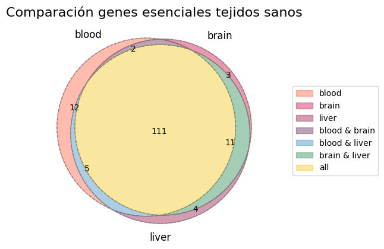

```python
v = venn3([gCS_blood, gCS_brain, gCS_liver], set_labels=('blood', 'brain', 'liver'))
c = venn3_circles([gCS_blood, gCS_brain, gCS_liver], linestyle='dashed', linewidth=1, color="grey")

# colores personalizados
colores = ['#FF5733', '#C70039', '#900C3F', '#571845', '#2E86C1', '#1D8348', '#F1C40F']

# Aplicar colores personalizados a los subconjuntos del diagrama de Venn
for area in ('100', '010', '001', '110', '101', '011', '111'):
    if v.get_patch_by_id(area):
        v.get_patch_by_id(area).set_color(colores[0])
        colores.append(colores.pop(0))  # Rota los colores para cada área

plt.legend(handles=[
    v.get_patch_by_id('100'), v.get_patch_by_id('010'), v.get_patch_by_id('001'),
    v.get_patch_by_id('110'), v.get_patch_by_id('101'), v.get_patch_by_id('011'),
    v.get_patch_by_id('111')
    ],
    labels=[
    'blood', 'brain', 'liver',
    'blood & brain', 'blood & liver', 'brain & liver',
    'all'
    ],
    loc='right', bbox_to_anchor=(1.5, 0.5))

plt.title("Comparación genes esenciales tejidos sanos", fontsize=16)

plt.show()
```

Como vemos hay 111 genes esenciales comunes entre los modelos sanos. A modo individual, se puede ver que cada tejido tiene genes que se expresan diferencialmente en esos tejidos en concreto, por ejemplo, la sangre tiene 12, el cerebro 3 genes, el higado 4 genes, la sangre y el cerebro comparten 2 genes, la sangre y el higado 5 genes, y el cerebro y el higado comparten 11 genes.

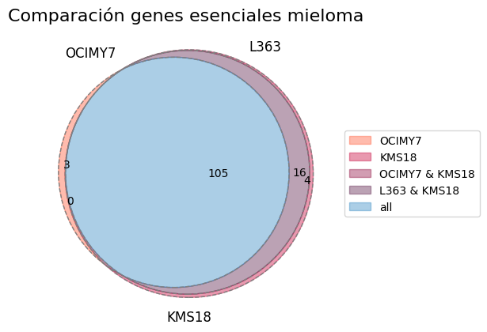

```python
v = venn3([gCS_OCIMY7, gCS_L363, gCS_KMS18], set_labels=('OCIMY7', 'L363', 'KMS18'))
c = venn3_circles([gCS_OCIMY7, gCS_L363, gCS_KMS18], linestyle='dashed', linewidth=1, color="grey")

#  colores personalizados
colores = ['#FF5733', '#C70039', '#900C3F', '#571845', '#2E86C1', '#1D8348', '#F1C40F']

# Aplicar colores personalizados a los subconjuntos del diagrama de Venn
for area in ('100', '010', '001', '110', '101', '011', '111'):
    if v.get_patch_by_id(area):
        v.get_patch_by_id(area).set_color(colores[0])
        colores.append(colores.pop(0))  # Rota los colores para cada área

plt.legend(handles=[
    v.get_patch_by_id('100'), v.get_patch_by_id('010'), v.get_patch_by_id('001'),
    v.get_patch_by_id('110'), v.get_patch_by_id('101'), v.get_patch_by_id('011'),
    v.get_patch_by_id('111')
    ],
    labels=[
    'OCIMY7', 'L363', 'KMS18',
    'OCIMY7 & L363', 'OCIMY7 & KMS18', 'L363 & KMS18',
    'all'
    ],
    loc='right', bbox_to_anchor=(1.5, 0.5))

plt.title("Comparación genes esenciales mieloma", fontsize=16)

plt.show()
```

Al mirar las lines de mieloma vemos que hay 105 genes en total que comparten los 3 modelos. Luego en específico, la linea OCIMY7 tiene 3 genes que no comparte con las demás, la KMS18 4 genes especificos. L363 y KMS18 comparten 16 genes. Tanto las lineas L363, como OCIMY17+KMS18 no tienen genes especificos

### Estrategia 1. Totales sanos vs comunes mieloma

Vamos a probar en esta primera estrategia a descartar todos los genes esenciales sanos para matar todas las lineas de mieloma.

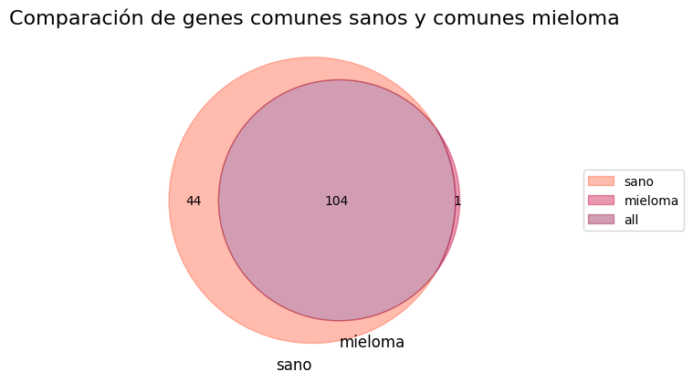

```python
v = venn2([genes_sanos, genes_comunes_mieloma], set_labels=('sano', 'mieloma'))

#  colores personalizados
colores = ['#FF5733', '#C70039', '#900C3F', '#571845', '#2E86C1', '#1D8348', '#F1C40F']

# Aplicar colores personalizados a los subconjuntos del diagrama de Venn
for area in ('10', '01', '11'):
    if v.get_patch_by_id(area):
        v.get_patch_by_id(area).set_color(colores[0])
        colores.append(colores.pop(0))  # Rota los colores para cada área

plt.legend(handles=[
    v.get_patch_by_id('10'), v.get_patch_by_id('01'), v.get_patch_by_id('11')
    ],
    labels=[
    'sano', 'mieloma', 'all'
    ],
    loc='right', bbox_to_anchor=(1.6, 0.5))

plt.title("Comparación de genes comunes sanos y comunes mieloma", fontsize=16)

plt.show()
```

Como vemos hay 1 gen candidato a derrotar estos modelos de mieloma. Vamos a ver qué gen es.

```python
genes_diana_mieloma = genes_comunes_mieloma.difference(genes_sanos)
```

Sacamos la informacion de los genes a partir de los id de ensembl

```python
mg = mygene.MyGeneInfo()
df=mg.querymany(genes_diana_mieloma, scopes='ensembl.gene', species=9606, as_dataframe=True)
df.iloc[:, [2, 3, 4]]
```

| query | entrezgene | name | symbol |
| --- | --- | --- | --- |
| ENSG00000137700 | 2542 | solute carrier family 37 member 4 | SLC37A4 |

El gen obtenido es el solute carrier family 37 member 4 (SLC37A4). Vamos a coger el gene_symbol para tener los dos simbolos en un diccionario

```python
genes_diana_mieloma2={}
for g in genes_diana_mieloma:
    gene = mg.getgene(g, fields='symbol')
    if "symbol" in gene:
        genes_diana_mieloma2[g]= gene["symbol"]
```

Vamos a ver en qué rutas están implicadas estos genes. Para ello buscamos en la base de datos KEGG.

```python
s = KEGG()

pathways_genes = []

for g in genes_diana_mieloma:
    gene = mg.getgene(g, fields='symbol')
    if "symbol" in gene:

        pathways = s.get_pathway_by_gene(gene["symbol"], "hsa")
        if pathways:
            for pathway_id, pathway_name in pathways.items():

                pathways_genes.append({"Gene": gene["symbol"], "Pathway_ID": pathway_id, "Pathway_Name": pathway_name})

df_pathways_genes = pd.DataFrame(pathways_genes)

df_pathways_genes
```

|  | Gene | Pathway_ID | Pathway_Name |
| --- | --- | --- | --- |
| 0 | SLC37A4 | hsa04973 | Carbohydrate digestion and absorption |

Vemos que este gen está intimamente relacionado con la digestion y absorción de carbohidratos

Vamos a buscar si hay articulos relacionados con nuestros genes diana. El codigo ha sido extraido y modificado de la pagina (https://marcobonzanini.com/2015/01/12/searching-pubmed-with-python/)

```python
def buscar_articulos(gene, disease, num_salida):
    query = f"{gene}[Title/Abstract] AND {disease}[Title/Abstract]"

    search_handle = Entrez.esearch(db="pubmed",
                                   term=query,
                                   retmax=num_salida)
    search_results = Entrez.read(search_handle)
    search_handle.close()

    pmids = search_results["IdList"]
    return pmids

def fetch_article_details(pmids):

    handle = Entrez.efetch(db="pubmed",
                           id=",".join(pmids),
                           rettype="medline",
                           retmode="xml")
    records = Entrez.read(handle)

    # Procesa y devuelve la información de cada artículo
    articles = []
    for record in records['PubmedArticle']:
        article = {
            "title": record.get("MedlineCitation", {}).get("Article", {}).get("ArticleTitle", ""),
            "authors": [author.get('ForeName', '') + ' ' + author.get('LastName', '') for author in record.get("MedlineCitation", {}).get("Article", {}).get("AuthorList", [])],
            "abstract": "".join(record.get("MedlineCitation", {}).get("Article", {}).get("Abstract", {}).get("AbstractText", []))
        }
        articles.append(article)
    handle.close()
    return articles
```

```python
tabla = {}
for g in genes_diana_mieloma2:
     gene_symbol= genes_diana_mieloma2[g]
     pmids=buscar_articulos(gene_symbol, "Multiple Myeloma", 1000000)
     tabla[gene_symbol] = len(pmids)

tabla = dict(sorted(tabla.items(), key=lambda item: item[1], reverse=True))

pd.DataFrame(tabla, index=['Número de artículos'])
```

|  | SLC37A4 |
| --- | --- |
| Número de artículos | 0 |

No encontramos ningún articulo relacionado.

```python
def buscar_go(ensembl_id) :
  server = "https://rest.ensembl.org"
  ext = "/xrefs/id/"+ensembl_id+"?external_db=GO;all_levels=1"

  r = requests.get(server+ext, headers={ "Content-Type" : "application/json"})

  if not r.ok:
    r.raise_for_status()
    sys.exit()

  decoded = r.json()
  lista_go=[]
  for r in decoded:
    for i in r:
      if i == "description" :
        if r[i] not in lista_go:
          lista_go.append(r[i])
  return lista_go
```

```python
buscar_go("ENSG00000137700") # solute carrier family 37 member 4	SLC37A4
```

```
['neutrophil homeostasis',
 'myeloid progenitor cell differentiation',
 'endoplasmic reticulum membrane',
 'glycogen metabolic process',
 'lactate metabolic process',
 'gluconeogenesis',
 'triglyceride metabolic process',
 'cellular calcium ion homeostasis',
 'response to nutrient',
 'steroid metabolic process',
 'response to glucose',
 'response to organic cyclic compound',
 'glucose-6-phosphate transmembrane transporter activity',
 'glucose-6-phosphate transport',
 'membrane',
 'transmembrane transporter activity',
 'neutrophil chemotaxis',
 'organelle membrane',
 'negative regulation of chemokine production',
 'post-embryonic hemopoiesis',
 'glucose homeostasis',
 'cholesterol homeostasis',
 'respiratory burst',
 'transmembrane transport',
 'glucose 6-phosphate:inorganic phosphate antiporter activity']
```

Vemos que está muy relacionado con el metabolismo de la glucosa y la homeostasis de neutrófilos

### Estrategia 2: Totales sanos vs totales mielomas

En este caso vamos a conservar todos los tejidos sanos y buscar targets que maten al menos a un modelo de mieloma multiple.

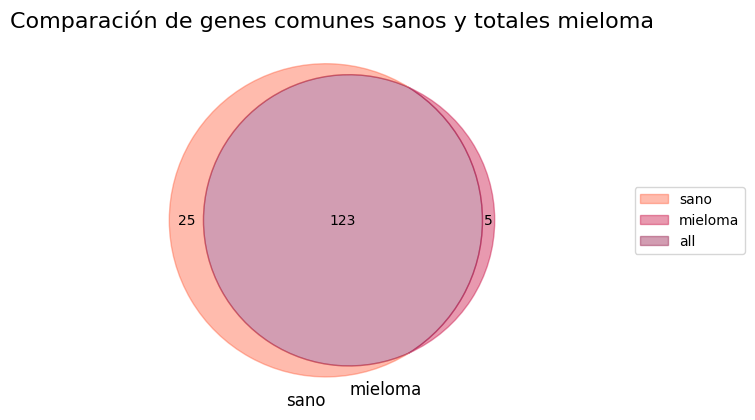

```python
v = venn2([genes_sanos, genes_mieloma], set_labels=('sano', 'mieloma'))

#  colores personalizados
colores = ['#FF5733', '#C70039', '#900C3F', '#571845', '#2E86C1', '#1D8348', '#F1C40F']

# Aplicar colores personalizados a los subconjuntos del diagrama de Venn
for area in ('10', '01', '11'):
    if v.get_patch_by_id(area):
        v.get_patch_by_id(area).set_color(colores[0])
        colores.append(colores.pop(0))  # Rota los colores para cada área

plt.legend(handles=[
    v.get_patch_by_id('10'), v.get_patch_by_id('01'), v.get_patch_by_id('11')
    ],
    labels=[
    'sano', 'mieloma', 'all'
    ],
    loc='right', bbox_to_anchor=(1.6, 0.5))

plt.title("Comparación de genes comunes sanos y totales mieloma", fontsize=16)

plt.show()
```

Encontramos ahora 5 dianas para matar al menos 1 modelo de mieloma

```python
genes_diana_mieloma = genes_mieloma.difference(genes_sanos)
```

```python
mg = mygene.MyGeneInfo()
df=mg.querymany(genes_diana_mieloma, scopes='ensembl.gene', species=9606, as_dataframe=True)
df.iloc[:, [2, 3, 4]]
```

| query | entrezgene | name | symbol |
| --- | --- | --- | --- |
| ENSG00000111726 | 55907 | cytidine monophosphate N-acetylneuraminic acid... | CMAS |
| ENSG00000134184 | 2944 | glutathione S-transferase mu 1 | GSTM1 |
| ENSG00000164414 | 10559 | solute carrier family 35 member A1 | SLC35A1 |
| ENSG00000137700 | 2542 | solute carrier family 37 member 4 | SLC37A4 |
| ENSG00000173614 | 64802 | nicotinamide nucleotide adenylyltransferase 1 | NMNAT1 |

```python
genes_diana_mieloma2={}
for g in genes_diana_mieloma:
    gene = mg.getgene(g, fields='symbol')
    if "symbol" in gene:
        genes_diana_mieloma2[g]= gene["symbol"]
```

```python
s = KEGG()

pathways_genes = []

for g in genes_diana_mieloma:
    gene = mg.getgene(g, fields='symbol')
    if "symbol" in gene:

        pathways = s.get_pathway_by_gene(gene["symbol"], "hsa")
        if pathways:
            for pathway_id, pathway_name in pathways.items():

                pathways_genes.append({"Gene": gene["symbol"], "Pathway_ID": pathway_id, "Pathway_Name": pathway_name})

df_pathways_genes = pd.DataFrame(pathways_genes)

df_pathways_genes
```

|  | Gene | Pathway_ID | Pathway_Name |
| --- | --- | --- | --- |
| 0 | CMAS | hsa00520 | Amino sugar and nucleotide sugar metabolism |
| 1 | CMAS | hsa01100 | Metabolic pathways |
| 2 | CMAS | hsa01250 | Biosynthesis of nucleotide sugars |
| 3 | GSTM1 | hsa00480 | Glutathione metabolism |
| 4 | GSTM1 | hsa00980 | Metabolism of xenobiotics by cytochrome P450 |
| 5 | GSTM1 | hsa00982 | Drug metabolism - cytochrome P450 |
| 6 | GSTM1 | hsa00983 | Drug metabolism - other enzymes |
| 7 | GSTM1 | hsa01100 | Metabolic pathways |
| 8 | GSTM1 | hsa01524 | Platinum drug resistance |
| 9 | GSTM1 | hsa05200 | Pathways in cancer |
| 10 | GSTM1 | hsa05204 | Chemical carcinogenesis - DNA adducts |
| 11 | GSTM1 | hsa05207 | Chemical carcinogenesis - receptor activation |
| 12 | GSTM1 | hsa05208 | Chemical carcinogenesis - reactive oxygen species |
| 13 | GSTM1 | hsa05225 | Hepatocellular carcinoma |
| 14 | GSTM1 | hsa05418 | Fluid shear stress and atherosclerosis |
| 15 | SLC37A4 | hsa04973 | Carbohydrate digestion and absorption |
| 16 | NMNAT1 | hsa00760 | Nicotinate and nicotinamide metabolism |
| 17 | NMNAT1 | hsa01100 | Metabolic pathways |
| 18 | NMNAT1 | hsa01240 | Biosynthesis of cofactors |

```python
tabla = {}
for g in genes_diana_mieloma2:
     gene_symbol= genes_diana_mieloma2[g]
     pmids=buscar_articulos(gene_symbol, "Multiple Myeloma", 1000000)
     tabla[gene_symbol] = len(pmids)

tabla = dict(sorted(tabla.items(), key=lambda item: item[1], reverse=True))

pd.DataFrame(tabla, index=['Número de artículos'])
```

|  | GSTM1 | CMAS | SLC35A1 | SLC37A4 | NMNAT1 |
| --- | --- | --- | --- | --- | --- |
| Número de artículos | 8 | 0 | 0 | 0 | 0 |

Vemos que el único gen en el que se han publicado articulos en el contexto del mieloma multiple es el GSTM1 (glutathione S-transferase mu 1). Vamos a ver los articulos sin estan relacionados con ese gen en concreto.

```python
pmids = buscar_articulos("GSTM1", "Multiple Myeloma", 5)

articulos = fetch_article_details(pmids)

for articulo in articulos:
     print(f"Title: {articulo['title']}\nAuthors: {', '.join(articulo['authors'])}\nAbstract: {''.join(articulo['abstract'])}\n\n")
```

```
Title: The Association of <i>GSTT1, GSTM1</i>, and <i>TNF-</i>α Polymorphisms With the Risk and Outcome in Multiple Myeloma.
Authors: Szymon Zmorzyński, Sylwia Popek-Marciniec, Aneta Szudy-Szczyrek, Magdalena Wojcierowska-Litwin, Iwona Korszeń-Pilecka, Sylwia Chocholska, Wojciech Styk, Marek Hus, Agata A Filip
Abstract: Oxidative stress and systemic inflammation are closely linked with increased risk of cancer development. Tumor necrosis factor alpha (TNF-α) is one of the pro-inflammatory cytokines. Glutathione S-transferases (GSTs) are enzymes involved in oxidative stress handling. Polymorphisms of genes…


Title: VEGF, VEGFR2 and GSTM1 polymorphisms in outcome of multiple myeloma patients treated with thalidomide-based regimens.
Authors: L Lopes-Aguiar, M T Delamain, A B C Brito, G J Lourenço, E F D Costa, G B Oliveira, J Vassallo, C A De Souza, C S P Lima
Abstract:


Title: [Relationship of GSTT1 and GSTM1 Gene Polymorphisms and PAH-DNA Adducts with Pathogenesis of Multiple Myeloma].
Authors: Yuan-Yuan Wang, Wei Wang, Jie Yang, Guang-Lun Li, Li-Kun Zhuang, Li-Li Lu
Abstract: To explore the relationship of GSTT1, GSTM1 gene polymorphisms and PAH-DNA adduct with pathogenesis of multiple myeloma.The bone marrow samples from 37 newly-diagnosed MM patients and 52 healthy peoples as controls were collected; the PCR-based restriction fragment length polymorphism (PCR…


Title: Polymorphisms of VEGF, GSTM1 and GSTT1 genes in multiple myeloma risk.
Authors: Eliel W Faber, Gustavo J Lourenço, Manoela M Ortega, Irene Lorand-Metze, Carmino A De Souza, Carmen S P Lima
Abstract:


Title: Protective role of CYP1A1*2A in the development of multiple myeloma.
Authors: Seong-Ho Kang, Tae Young Kim, Ho Young Kim, Jong-Hyun Yoon, Han-Ik Cho, Sung Soo Yoon, Dae Hee Kang, Cheol Won Suh, Jae Hoon Lee, Dong Soon Lee
Abstract: We had previously reported the association of the NQO1*2/*2 polymorphism with a decreased risk for multiple myeloma (MM) in Koreans (odds ratio, OR, 0.24; 95% confidence interval, CI, 0.01-0.68). The associations of polymorphisms of other metabolizing enzymes (CYP1A1, GSTM1 and GSTT1) with…
```

Observamos que ese gen sí está relacionado con la patogénesis del mieloma multiple, lo que podemos considerarlo un candidato para buscar terapias.

```python
buscar_go("ENSG00000134184") # GSTM1 (glutathione S-transferase mu 1)
```

```
['glutathione transferase activity',
 'cytoplasm',
 'cytosol',
 'lipid metabolic process',
 'prostaglandin metabolic process',
 'glutathione metabolic process',
 'transferase activity',
 'nitrobenzene metabolic process',
 'enzyme binding',
 'xenobiotic catabolic process',
 'identical protein binding',
 'protein homodimerization activity',
 'glutathione binding',
 'intercellular bridge',
 'hepoxilin biosynthetic process',
 'cellular detoxification of nitrogen compound',
 'glutathione derivative biosynthetic process']
```

Aquí observamos la gene ontology del gen GSTM1 (glutathione S-transferase mu 1) y podemos decir que participa en muchos proceso metabolicos clave de las células y que su alteración puede ser clave. Es una proteina que se encuentra en el citoplasma y participa en procesos enzimáticos

### Estrategia 3: Comunes sanos vs comunes mieloma

En esta estrategia vamos a sacrificar al menos un tejido. Es arriesgado porque tenemos el cerebro que es un organo que no tiene capacidad regenerativa. En el caso de la sangre y del hígado sí que existe la posibilidad de hacer un trasplante al paciente. Vamos a hacer la busqueda de estos genes.

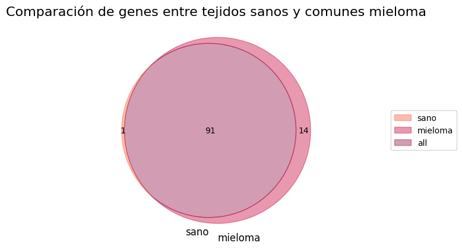

```python
v = venn2([genes_comunes_sano, genes_comunes_mieloma], set_labels=('sano', 'mieloma'))

#  colores personalizados
colores = ['#FF5733', '#C70039', '#900C3F', '#571845', '#2E86C1', '#1D8348', '#F1C40F']

# Aplicar colores personalizados a los subconjuntos del diagrama de Venn
for area in ('10', '01', '11'):
    if v.get_patch_by_id(area):
        v.get_patch_by_id(area).set_color(colores[0])
        colores.append(colores.pop(0))  # Rota los colores para cada área

plt.legend(handles=[
    v.get_patch_by_id('10'), v.get_patch_by_id('01'), v.get_patch_by_id('11')
    ],
    labels=[
    'sano', 'mieloma', 'all'
    ],
    loc='right', bbox_to_anchor=(1.6, 0.5))

plt.title("Comparación de genes entre tejidos sanos y comunes mieloma", fontsize=16)

plt.show()
```

Podemos ver que se incrementa hasta 14 los genes que podrian ser targets para matar a todas las lineas de mieloma, a costa del sacrificio de algún tejido sano.

```python
genes_diana_mieloma = genes_comunes_mieloma.difference(genes_comunes_sano)
mg = mygene.MyGeneInfo()
df=mg.querymany(genes_diana_mieloma, scopes='ensembl.gene', species=9606, as_dataframe=True)
df.iloc[:, [2, 3, 4]]
```

| query | entrezgene | name | symbol |
| --- | --- | --- | --- |
| ENSG00000110536 | 114971 | protein tyrosine phosphatase mitochondrial 1 | PTPMT1 |
| ENSG00000084774 | 790 | carbamoyl-phosphate synthetase 2, aspartate tr... | CAD |
| ENSG00000112759 | 2030 | solute carrier family 29 member 1 (Augustine b... | SLC29A1 |
| ENSG00000162368 | 51727 | cytidine/uridine monophosphate kinase 1 | CMPK1 |
| ENSG00000135069 | 29968 | phosphoserine aminotransferase 1 | PSAT1 |
| ENSG00000186104 | 120227 | cytochrome P450 family 2 subfamily R member 1 | CYP2R1 |
| ENSG00000013375 | 5238 | phosphoglucomutase 3 | PGM3 |
| ENSG00000108439 | 55163 | pyridoxamine 5'-phosphate oxidase | PNPO |
| ENSG00000087157 | 9489 | phosphatidylglycerophosphate synthase 1 | PGS1 |
| ENSG00000103502 | 10423 | CDP-diacylglycerol--inositol 3-phosphatidyltra... | CDIPT |
| ENSG00000137700 | 2542 | solute carrier family 37 member 4 | SLC37A4 |
| ENSG00000160209 | 8566 | pyridoxal kinase | PDXK |
| ENSG00000109814 | 7358 | UDP-glucose 6-dehydrogenase | UGDH |
| ENSG00000134326 | 129607 | cytidine/uridine monophosphate kinase 2 | CMPK2 |

```python
genes_diana_mieloma2={}
for g in genes_diana_mieloma:
    gene = mg.getgene(g, fields='symbol')
    if "symbol" in gene:
        genes_diana_mieloma2[g]= gene["symbol"]
```

```python
s = KEGG()

pathways_genes = []

for g in genes_diana_mieloma:
    gene = mg.getgene(g, fields='symbol')
    if "symbol" in gene:

        pathways = s.get_pathway_by_gene(gene["symbol"], "hsa")
        if pathways:
            for pathway_id, pathway_name in pathways.items():

                pathways_genes.append({"Gene": gene["symbol"], "Pathway_ID": pathway_id, "Pathway_Name": pathway_name})

df_pathways_genes = pd.DataFrame(pathways_genes)

df_pathways_genes
```

|  | Gene | Pathway_ID | Pathway_Name |
| --- | --- | --- | --- |
| 0 | CAD | hsa00240 | Pyrimidine metabolism |
| 1 | CAD | hsa00250 | Alanine, aspartate and glutamate metabolism |
| 2 | CAD | hsa01100 | Metabolic pathways |
| 3 | CAD | hsa01240 | Biosynthesis of cofactors |
| 4 | SLC29A1 | hsa05034 | Alcoholism |
| 5 | CMPK1 | hsa00240 | Pyrimidine metabolism |
| 6 | CMPK1 | hsa00983 | Drug metabolism - other enzymes |
| 7 | CMPK1 | hsa01100 | Metabolic pathways |
| 8 | CMPK1 | hsa01232 | Nucleotide metabolism |
| 9 | CMPK1 | hsa01240 | Biosynthesis of cofactors |
| 10 | PSAT1 | hsa00260 | Glycine, serine and threonine metabolism |
| 11 | PSAT1 | hsa00270 | Cysteine and methionine metabolism |
| 12 | PSAT1 | hsa00750 | Vitamin B6 metabolism |
| 13 | PSAT1 | hsa01100 | Metabolic pathways |
| 14 | PSAT1 | hsa01200 | Carbon metabolism |
| 15 | PSAT1 | hsa01230 | Biosynthesis of amino acids |
| 16 | PSAT1 | hsa01240 | Biosynthesis of cofactors |
| 17 | CYP2R1 | hsa00100 | Steroid biosynthesis |
| 18 | CYP2R1 | hsa01100 | Metabolic pathways |
| 19 | PGM3 | hsa00520 | Amino sugar and nucleotide sugar metabolism |
| 20 | PGM3 | hsa01100 | Metabolic pathways |
| 21 | PGM3 | hsa01250 | Biosynthesis of nucleotide sugars |
| 22 | PNPO | hsa00750 | Vitamin B6 metabolism |
| 23 | PNPO | hsa01100 | Metabolic pathways |
| 24 | PNPO | hsa01240 | Biosynthesis of cofactors |
| 25 | PGS1 | hsa00564 | Glycerophospholipid metabolism |
| 26 | PGS1 | hsa01100 | Metabolic pathways |
| 27 | CDIPT | hsa00562 | Inositol phosphate metabolism |
| 28 | CDIPT | hsa00564 | Glycerophospholipid metabolism |
| 29 | CDIPT | hsa01100 | Metabolic pathways |
| 30 | CDIPT | hsa04070 | Phosphatidylinositol signaling system |
| 31 | SLC37A4 | hsa04973 | Carbohydrate digestion and absorption |
| 32 | PDXK | hsa00750 | Vitamin B6 metabolism |
| 33 | PDXK | hsa01100 | Metabolic pathways |
| 34 | PDXK | hsa01240 | Biosynthesis of cofactors |
| 35 | UGDH | hsa00040 | Pentose and glucuronate interconversions |
| 36 | UGDH | hsa00053 | Ascorbate and aldarate metabolism |
| 37 | UGDH | hsa00520 | Amino sugar and nucleotide sugar metabolism |
| 38 | UGDH | hsa01100 | Metabolic pathways |
| 39 | UGDH | hsa01240 | Biosynthesis of cofactors |
| 40 | UGDH | hsa01250 | Biosynthesis of nucleotide sugars |
| 41 | CMPK2 | hsa00240 | Pyrimidine metabolism |
| 42 | CMPK2 | hsa01100 | Metabolic pathways |
| 43 | CMPK2 | hsa01232 | Nucleotide metabolism |
| 44 | CMPK2 | hsa01240 | Biosynthesis of cofactors |

Vamos a ver si se han publicado articulos con estos genes.

```python
tabla = {}
for g in genes_diana_mieloma2:
     gene_symbol= genes_diana_mieloma2[g]
     pmids=buscar_articulos(gene_symbol, "Multiple Myeloma", 1000000)
     tabla[gene_symbol] = len(pmids)

tabla = dict(sorted(tabla.items(), key=lambda item: item[1], reverse=True))

pd.DataFrame(tabla, index=['Número de artículos'])
```

|  | CAD | SLC29A1 | PTPMT1 | CMPK1 | PSAT1 | CYP2R1 | PGM3 | PNPO | PGS1 | CDIPT | SLC37A4 | PDXK | UGDH | CMPK2 |
| --- | --- | --- | --- | --- | --- | --- | --- | --- | --- | --- | --- | --- | --- | --- |
| Número de artículos | 28 | 1 | 0 | 0 | 0 | 0 | 0 | 0 | 0 | 0 | 0 | 0 | 0 | 0 |

Vemos que el gen CAD (carbamoyl-phosphate synthetase 2, aspartate transcarbamylase, and dihydroorotase) tiene 28 articulos y SLC29A1 (solute carrier family 29 member 1) 1 articulo. El resto no se han encontrado articulos. Vamos a ver los titulos de los articulos de estos genes.

```python
pmids = buscar_articulos("CAD", "Multiple Myeloma", 28)

articulos = fetch_article_details(pmids)

for articulo in articulos:
     print(f"Title: {articulo['title']}\nAuthors: {', '.join(articulo['authors'])}\nAbstract: {''.join(articulo['abstract'])}\n\n")
```

```
Title: Impact of Clinical Parameters and Induction Regimens on Peripheral Blood Stem-Cell Mobilization and Collection in Multiple Myeloma Patients.
Authors: Sandra Sauer, Lennart Hieke, Juliane Brandt, Carsten Müller-Tidow, Anita Schmitt, Joseph Kauer, Katharina Kriegsmann
Abstract: High-dose chemotherapy (HDCT) followed by autologous blood stem-cell transplantation (ABSCT) remains the standard consolidation therapy for newly diagnosed eligible multiple myeloma (MM) patients. As a prerequisite, peripheral blood stem cells (PBSCs) must be mobilized and collected by leu…


Title: Refractory cold agglutinin disease successfully treated with daratumumab. A case report and review of literature.
Authors: Abdelaziz Mohamed, Mohammed Alkhatib, Awni Alshurafa, Halima El Omri
Abstract: Cold agglutinin disease (CAD) is immune-mediated hemolytic anemia. The disease is caused by cold reactive autoantibodies that induce hemolysis through the activation of the complement pathway. Most patients with CAD are elderly, and half may have refractory CAD that may not respond to the …


Title: A CNN-based unified framework utilizing projection loss in unison with label noise handling for multiple Myeloma cancer diagnosis.
Authors: Shiv Gehlot, Anubha Gupta, Ritu Gupta
Abstract: Multiple Myeloma (MM) is a malignancy of plasma cells. Similar to other forms of cancer, it demands prompt diagnosis for reducing the risk of mortality. The conventional diagnostic tools are resource-intense and hence, these solutions are not easily scalable for extending their reach to th…


Title: A descriptive cost-analysis of MYX.1/MCRN003, a phase 2 clinical trial evaluating high-dose weekly carfilzomib, cyclophosphamide, and dexamethasone in relapsed and refractory multiple myeloma.
Authors: Bethany E Monteith, Christopher P Venner, Matthew C Cheung, Joe Pater, Lois Shepherd, Harriet Richardson, Donna Reece, Engin Gul, Marc Lalancette, Vincent Castonguay, Vishal Kukreti, Rodger Tiedemann, Chai Phua, Sita Bhella, Jill Dudebout, Max Sherry, Hope Yen, Bingshu E Chen, Annette E Hay
Abstract: The prevalence of multiple myeloma is increasing and there is a need to evaluate escalating therapy costs (Canadian Cancer Statistics A, 2020). The MYX.1 phase II trial showed that high-dose weekly carfilzomib, cyclophosphamide, and dexamethasone (wKCD) is efficacious in relapsed and refra…


Title: The Immunomodulatory Effect and Clinical Efficacy of Daratumumab in a Patient With Cold Agglutinin Disease.
Authors: Anna Zaninoni, Juri A Giannotta, Anna Gallì, Rosangela Artuso, Paola Bianchi, Luca Malcovati, Wilma Barcellini, Bruno Fattizzo
Abstract: Daratumumab is a monoclonal antibody directed against the transmembrane glycoprotein CD38 expressed on plasma cells and lymphoplasmocytes, with a proven efficacy in multiple myeloma. Here we show its clinical efficacy in a patient with cold agglutinin disease (CAD) relapsed after multiple …


Title: Development of Multiple Myeloma of the IgA Type in a Patient with Cold Agglutinin Disease: Transformation or Coincidence?
Authors: Øystein Sefland, Ulla Randen, Sigbjørn Berentsen
Abstract: Cold agglutinin disease (CAD) is an autoimmune hemolytic anemia and a distinct, clonal bone marrow lymphoproliferative disorder, characterized in most cases by a monoclonal IgMκ serum protein. We describe a CAD patient presenting with a monoclonal immunoglobulin of the IgA<i>λ</i> class. F…


Title: GRP78 modulates cell adhesion markers in prostate Cancer and multiple myeloma cell lines.
Authors: Christopher N Cultrara, Stephen D Kozuch, Poornema Ramasundaram, Claudia J Heller, Sunil Shah, Adah E Beck, David Sabatino, Jenny Zilberberg
Abstract: Glucose regulated protein 78 (GRP78) is a resident chaperone of the endoplasmic reticulum and a master regulator of the unfolded protein response under physiological and pathological cell stress conditions. GRP78 is overexpressed in many cancers, regulating a variety of signaling pathways …


Title: Comparison of biosimilar filgrastim, originator filgrastim, and lenograstim for autologous stem cell mobilization in patients with multiple myeloma.
Authors: Katharina Lisenko, Marc-Andrea Baertsch, Renate Meiser, Petra Pavel, Thomas Bruckner, Mark Kriegsmann, Anita Schmitt, Mathias Witzens-Harig, Anthony D Ho, Jens Hillengass, Patrick Wuchter
Abstract: Granulocyte-colony-stimulating factor (G-CSF) originators such as filgrastim (Neupogen) and lenograstim (Granocyte) are widely used for peripheral blood stem cell (PBSC) mobilization. In recent years, biosimilar agents have been approved for the same indications. The aim of this retrospect…


```

[output cut: 83 more lines]

```


Title: OPP-EBV-CAD regimen as salvage treatment in advanced refractory or resistant multiple myeloma.
Authors: M Colombi, A Guffanti, A Alietti, M L Latargia, C Vener, A T Maiolo, L Baldini
Abstract: With the aim of developing an effective therapy for heavily pretreated refractory MM outpatients, we evaluated the OPPEBVCAD regimen, a Hodgkin's disease-derived protocol that includes many drugs effective in MM administered in a sequential schedule. Twenty-two pts aged 42-72 years, with s…


Title: Cyclophosphamide, adriamycin and dexamethasone (CAD) is a highly effective therapy for patients with advanced multiple myeloma.
Authors: H Szelényi, E D Kreuser, U Keilholz, H D Menssen, C Keitel-Wittig, J Siehl, W Knauf, E Thiel
Abstract: Patients with advanced multiple myeloma (stage III or progressive myeloma) received the CAD protocol every three weeks: cyclophosphamide 200 mg/m2 i.v./orally days 1-4, adriamycin 30 mg/m2 i.v. on day 1 and dexamethasone 40 mg p.o. days 1-4.Forty-six patients with a median age of sixty yea…


Title: [Hypercirculatory heart failure in a patient with plasmacytic leukemia].
Authors: E Goncalvesová, E Uhliariková, A Vahancík, R Kohn, J Gyarfás
Abstract: High cardiac output failure/state (HCOF) is regular feature of some illnesses e.g. thiamine deficiency, hyperthyroidism, severe anemia, Paget's disease or arteriovenous fistulae. HCOF in multiple myeloma is reported quite rarely. 31-year-old man was admitted because of fatigue, dyspnea and…
```

Como vemos, el CAD también son siglas de otro tipo de productos, moleculas o terapias, como "Cold agglutinin disease", "cyclophosphamide/adriamycin/dexamethasone", "N-cadherin", pero ninguna al gen tenemos como target, por lo que todavia no se ha descrito.

```python
pmids = buscar_articulos("SLC29A1", "Multiple Myeloma", 100000)

articulos = fetch_article_details(pmids)

for articulo in articulos:
     print(f"Title: {articulo['title']}\nAuthors: {', '.join(articulo['authors'])}\nAbstract: {''.join(articulo['abstract'])}\n\n")
```

```
Title: Risk Alleles for Multiple Myeloma Susceptibility in ADME Genes.
Authors: Francesca Scionti, Giuseppe Agapito, Daniele Caracciolo, Caterina Riillo, Katia Grillone, Mario Cannataro, Maria Teresa Di Martino, Pierosandro Tagliaferri, Pierfrancesco Tassone, Mariamena Arbitrio
Abstract: The cause of multiple myeloma (MM) remains largely unknown. Several pieces of evidence support the involvement of genetic and multiple environmental factors (i.e., chemical agents) in MM onset. The inter-individual variability in the bioactivation, detoxification, and clearance of chemical…
```

En cambio, sí vemos que SLC29A1 ha sido encontrado en pacientes en un estudio a gran escala en un articulo de Francesca Scionti.

Vamos a ver qué gene ontology tienen el gen CAD y SLC29A1 y ver su de qué manera está relacionado con el mieloma multiple.

```python
buscar_go("ENSG00000084774") # Gen CAD
```

```
['nucleotide binding',
 'liver development',
 'catalytic activity',
 'aspartate carbamoyltransferase activity',
 'carbamoyl-phosphate synthase (glutamine-hydrolyzing) activity',
 'dihydroorotase activity',
 'protein kinase activity',
 'ATP binding',
 'nucleus',
 'cytoplasm',
 'cytosol',
 "'de novo' pyrimidine nucleobase biosynthetic process",
 'pyrimidine nucleotide biosynthetic process',
 'UDP biosynthetic process',
 'UTP biosynthetic process',
 'amino acid metabolic process',
 'glutamine metabolic process',
 'xenobiotic metabolic process',
 'nitrogen compound metabolic process',
 'heart development',
 'female pregnancy',
 'lactation',
 'metabolic process',
 'zinc ion binding',
 'response to amine',
 'membrane',
 'nuclear matrix',
 'amino acid binding',
 'transferase activity',
 'carboxyl- or carbamoyltransferase activity',
 'hydrolase activity',
 'hydrolase activity, acting on carbon-nitrogen (but not peptide) bonds',
 'hydrolase activity, acting on carbon-nitrogen (but not peptide) bonds, in cyclic amides',
 'ligase activity',
 'peptidyl-threonine phosphorylation',
 'heterocycle biosynthetic process',
 'citrulline biosynthetic process',
 'enzyme binding',
 'response to caffeine',
 'animal organ regeneration',
 'response to insulin',
 'protein-containing complex',
 'response to testosterone',
 'response to starvation',
 'identical protein binding',
 'cell projection',
 'neuronal cell body',
 'terminal bouton',
 "'de novo' UMP biosynthetic process",
 'primary metabolic process',
 'cellular nitrogen compound biosynthetic process',
 'small molecule metabolic process',
 'protein autophosphorylation',
 'metal ion binding',
 'response to cortisol',
 'extracellular exosome',
 'aspartate binding',
 'cellular response to epidermal growth factor stimulus',
 'cellular response to xenobiotic stimulus',
 'organonitrogen compound metabolic process',
 'organic substance biosynthetic process']
```

El gen CAD está relacionado con el desarrollo del hígado por lo que podría matar, además de al tejido de mieloma, también al hígado. También vemos que está presente el desarrollo del corazón, es gen clave durante el embarazo. Por lo que no parece buena idea utilizar este gen para bloquearlo.

```python
buscar_go("ENSG00000112759") # Gen SLC29A1
```

```
['neurotransmitter uptake',
 'neurotransmitter transmembrane transporter activity',
 'nucleoside transmembrane transporter activity',
 'plasma membrane',
 'nucleobase-containing compound metabolic process',
 'xenobiotic metabolic process',
 'neurotransmitter transport',
 'xenobiotic transmembrane transport',
 'adenine transmembrane transporter activity',
 'guanine transmembrane transporter activity',
 'uracil transmembrane transporter activity',
 'purine nucleoside transmembrane transporter activity',
 'cytidine transmembrane transporter activity',
 'uridine transmembrane transporter activity',
 'pyrimidine- and adenine-specific:sodium symporter activity',
 'nucleobase transport',
 'adenine transport',
 'nucleoside transport',
 'purine nucleoside transmembrane transport',
 'cytidine transport',
 'uridine transport',
 'membrane',
 'basolateral plasma membrane',
 'apical plasma membrane',
 'adenosine transport',
 'inosine transport',
 'hypoxanthine transport',
 'thymine transport',
 'pyrimidine-containing compound transmembrane transport',
 'transport across blood-brain barrier',
 'nucleoside transmembrane transport',
 'guanine transmembrane transport',
 'uracil transmembrane transport',
 'pyrimidine nucleobase transmembrane transport',
 'purine nucleobase transmembrane transport',
 'lactation',
 'excitatory postsynaptic potential',
 'cellular response to glucose stimulus',
 'cellular response to hypoxia',
 'presynapse',
 'postsynapse']
```

El gen SLC29A1 tampoco parece buena diana porque está relacionado con la actividad neurotransmisora. De los 3 tejidos sanos que tenemos, el unico que no podemos tocar es el cerebro, por lo que no parece tampoco buena diana.

### Estrategia 4. Comunes sanos vs totales mieloma

En esta estrategia sacrificamos algun tejido sano para matar al menos un tipo de mieloma. La peor estrategia y más arriesgada.

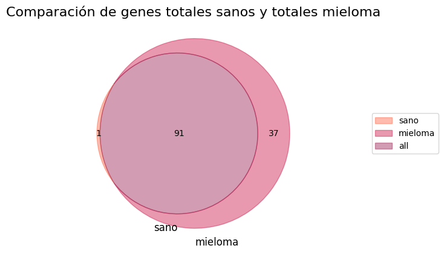

```python
v = venn2([genes_comunes_sano, genes_mieloma], set_labels=('sano', 'mieloma'))

#  colores personalizados
colores = ['#FF5733', '#C70039', '#900C3F', '#571845', '#2E86C1', '#1D8348', '#F1C40F']

# Aplicar colores personalizados a los subconjuntos del diagrama de Venn
for area in ('10', '01', '11'):
    if v.get_patch_by_id(area):
        v.get_patch_by_id(area).set_color(colores[0])
        colores.append(colores.pop(0))  # Rota los colores para cada área

plt.legend(handles=[
    v.get_patch_by_id('10'), v.get_patch_by_id('01'), v.get_patch_by_id('11')
    ],
    labels=[
    'sano', 'mieloma', 'all'
    ],
    loc='right', bbox_to_anchor=(1.6, 0.5))

plt.title("Comparación de genes totales sanos y totales mieloma", fontsize=16)

plt.show()
```

Vemos que incrementamos hasta 37 los candidatos.

```python
genes_diana_mieloma = genes_mieloma.difference(genes_comunes_sano)
mg = mygene.MyGeneInfo()
df=mg.querymany(genes_diana_mieloma, scopes='ensembl.gene', species=9606, as_dataframe=True)
df.iloc[:, [2, 3, 4]]
```

| query | entrezgene | name | symbol |
| --- | --- | --- | --- |
| ENSG00000163344 | 10654 | phosphomevalonate kinase | PMVK |
| ENSG00000147155 | 10682 | EBP cholestenol delta-isomerase | EBP |
| ENSG00000160285 | 4047 | lanosterol synthase | LSS |
| ENSG00000112759 | 2030 | solute carrier family 29 member 1 (Augustine b... | SLC29A1 |
| ENSG00000116133 | 1718 | 24-dehydrocholesterol reductase | DHCR24 |
| ENSG00000001630 | 1595 | cytochrome P450 family 51 subfamily A member 1 | CYP51A1 |
| ENSG00000111726 | 55907 | cytidine monophosphate N-acetylneuraminic acid... | CMAS |
| ENSG00000023909 | 2730 | glutamate-cysteine ligase modifier subunit | GCLM |
| ENSG00000013375 | 5238 | phosphoglucomutase 3 | PGM3 |
| ENSG00000109929 | 6309 | sterol-C5-desaturase | SC5D |
| ENSG00000112972 | 3157 | 3-hydroxy-3-methylglutaryl-CoA synthase 1 | HMGCS1 |
| ENSG00000103502 | 10423 | CDP-diacylglycerol--inositol 3-phosphatidyltra... | CDIPT |
| ENSG00000087157 | 9489 | phosphatidylglycerophosphate synthase 1 | PGS1 |
| ENSG00000164414 | 10559 | solute carrier family 35 member A1 | SLC35A1 |
| ENSG00000001084 | 2729 | glutamate-cysteine ligase catalytic subunit | GCLC |
| ENSG00000134326 | 129607 | cytidine/uridine monophosphate kinase 2 | CMPK2 |
| ENSG00000132196 | 51478 | hydroxysteroid 17-beta dehydrogenase 7 | HSD17B7 |
| ENSG00000175592 | 8061 | FOS like 1, AP-1 transcription factor subunit | FOSL1 |
| ENSG00000134184 | 2944 | glutathione S-transferase mu 1 | GSTM1 |
| ENSG00000160209 | 8566 | pyridoxal kinase | PDXK |
| ENSG00000167508 | 4597 | mevalonate diphosphate decarboxylase | MVD |
| ENSG00000110536 | 114971 | protein tyrosine phosphatase mitochondrial 1 | PTPMT1 |
| ENSG00000135437 | 5959 | retinol dehydrogenase 5 | RDH5 |
| ENSG00000084774 | 790 | carbamoyl-phosphate synthetase 2, aspartate tr... | CAD |
| ENSG00000162368 | 51727 | cytidine/uridine monophosphate kinase 1 | CMPK1 |
| ENSG00000100983 | 2937 | glutathione synthetase | GSS |
| ENSG00000113161 | 3156 | 3-hydroxy-3-methylglutaryl-CoA reductase | HMGCR |
| ENSG00000147383 | 50814 | NAD(P) dependent steroid dehydrogenase-like | NSDHL |
| ENSG00000079459 | 2222 | farnesyl-diphosphate farnesyltransferase 1 | FDFT1 |
| ENSG00000135069 | 29968 | phosphoserine aminotransferase 1 | PSAT1 |
| ENSG00000186104 | 120227 | cytochrome P450 family 2 subfamily R member 1 | CYP2R1 |
| ENSG00000108439 | 55163 | pyridoxamine 5'-phosphate oxidase | PNPO |
| ENSG00000137700 | 2542 | solute carrier family 37 member 4 | SLC37A4 |
| ENSG00000110921 | 4598 | mevalonate kinase | MVK |
| ENSG00000104549 | 6713 | squalene epoxidase | SQLE |
| ENSG00000109814 | 7358 | UDP-glucose 6-dehydrogenase | UGDH |
| ENSG00000173614 | 64802 | nicotinamide nucleotide adenylyltransferase 1 | NMNAT1 |

```python
genes_diana_mieloma2={}
for g in genes_diana_mieloma:
    gene = mg.getgene(g, fields='symbol')
    if "symbol" in gene:
        genes_diana_mieloma2[g]= gene["symbol"]
```

```python
s = KEGG()

pathways_genes = []

for g in genes_diana_mieloma:
    gene = mg.getgene(g, fields='symbol')
    if "symbol" in gene:

        pathways = s.get_pathway_by_gene(gene["symbol"], "hsa")
        if pathways:
            for pathway_id, pathway_name in pathways.items():

                pathways_genes.append({"Gene": gene["symbol"], "Pathway_ID": pathway_id, "Pathway_Name": pathway_name})

df_pathways_genes = pd.DataFrame(pathways_genes)

df_pathways_genes
```

|  | Gene | Pathway_ID | Pathway_Name |
| --- | --- | --- | --- |
| 0 | PMVK | hsa00900 | Terpenoid backbone biosynthesis |
| 1 | PMVK | hsa01100 | Metabolic pathways |
| 2 | PMVK | hsa04146 | Peroxisome |
| 3 | EBP | hsa00100 | Steroid biosynthesis |
| 4 | EBP | hsa01100 | Metabolic pathways |
| ... | ... | ... | ... |
| 116 | UGDH | hsa01240 | Biosynthesis of cofactors |
| 117 | UGDH | hsa01250 | Biosynthesis of nucleotide sugars |
| 118 | NMNAT1 | hsa00760 | Nicotinate and nicotinamide metabolism |
| 119 | NMNAT1 | hsa01100 | Metabolic pathways |
| 120 | NMNAT1 | hsa01240 | Biosynthesis of cofactors |

121 rows × 3 columns

```python
tabla = {}
for g in genes_diana_mieloma2:
     gene_symbol= genes_diana_mieloma2[g]
     pmids=buscar_articulos(gene_symbol, "Multiple Myeloma", 1000000)
     tabla[gene_symbol] = len(pmids)

tabla = dict(sorted(tabla.items(), key=lambda item: item[1], reverse=True))

pd.DataFrame(tabla, index=['Número de artículos'])
```

|  | MVD | CAD | EBP | GSTM1 | GCLM | LSS | GCLC | PMVK | SLC29A1 | HMGCS1 | ... | CMPK1 | GSS | FDFT1 | PSAT1 | CYP2R1 | PNPO | SLC37A4 | MVK | UGDH | NMNAT1 |
| --- | --- | --- | --- | --- | --- | --- | --- | --- | --- | --- | --- | --- | --- | --- | --- | --- | --- | --- | --- | --- | --- |
| Número de artículos | 84 | 28 | 19 | 8 | 4 | 3 | 2 | 1 | 1 | 1 | ... | 0 | 0 | 0 | 0 | 0 | 0 | 0 | 0 | 0 | 0 |

1 rows × 37 columns

Hay muchos genes descritos en el mieloma multiple. Vamos a echar un vistazo de los más publicados (quitando CAD y GSTM1 que lo hemos visto anteriormente).

```python
pmids = buscar_articulos("MVD", "Multiple Myeloma", 5)

articulos = fetch_article_details(pmids)

for articulo in articulos:
     print(f"Title: {articulo['title']}\nAuthors: {', '.join(articulo['authors'])}\nAbstract: {''.join(articulo['abstract'])}\n\n")
```

```
Title: A novel circRNA-miRNA-mRNA network revealed exosomal circ-ATP10A as a biomarker for multiple myeloma angiogenesis.
Authors: Manya Yu, Jie Yu, Yanyu Zhang, Xiaoqi Sun, Runjie Sun, Mengting Xia, Sumei Li, Xing Cui
Abstract: The importance of angiogenesis in multiple myeloma (MM) is unquestionable; however, to date, the success of antiangiogenic therapies has been fairly limited. Exosomal circular RNAs (circRNAs) have been proven to be pivotal players in angiogenesis in various cancers. Nevertheless, their rol…


Title: Regulatory role of DEPTOR‑mediated cellular autophagy and mitochondrial reactive oxygen species in angiogenesis in multiple myeloma.
Authors: Jizhen Wang, Junmin Chen, Dongbiao Qiu, Zhiyong Zeng
Abstract: DEPTOR, an inhibitor of mammalian target of rapamycin (mTOR), is essential for the survival of multiple myeloma (MM) cells. The expression level of DEPTOR is closely related to the prognosis of patients with MM treated with the antiangiogenic agent thalidomide; however, its role in the reg…


Title: [Correlation between Expression of CXCL12, CXCR4, VEGF, MVD and Prognosis in Patients with Multiple Myeloma].
Authors: Ke Zhang, Jun Zhou, Xiao-Ming Li, Chun-Lan Huang
Abstract: To investigate the expressions of stromal cell-derived factor (CXCL12), stromal cell-derived factor receptor (CXCR4), vascular endothelial growth factor (VEGF) and microvessel density (MVD) in bone marrow microsputum of patients with multiple myeloma (MM) and their correlation with the pro…


Title: Evaluation of Angiogenesis in Multiple Myeloma by VEGF Immunoexpression and Microvessel Density.
Authors: Anshu Palta, Manveen Kaur, Anita Tahlan, Kislay Dimri
Abstract: <b>Background</b>  Multiple myeloma (MM) is a plasma cell disorder characterized by monoclonal proliferation of plasma cells in bone marrow. Plasmablastic MM is a morphologic subset of MM, containing ≥2% plasmablasts of all plasma cells. <b>Methods</b>  The study included 30 consecutively …


Title: Development of an Automated Image Analyzer for Microvessel Density Measurement in Bone Marrow Biopsies.
Authors: Yousun Chung, Seungwon Shin, Hyoeun Shim, Ji Yeon Sohn, Dong Eun Lee, Hyewon Lee, Hyeon Seok Eom, Kwang Gi Kim, Sun Young Kong
Abstract: Angiogenesis is important for the proliferation and survival of multiple myeloma (MM) cells. Bone marrow (BM) microvessel density (MVD) is a useful marker of angiogenesis and an increase in MVD can be used as a marker of poor prognosis in MM patients. We developed an automated image analyz…
```

El caso del gene MVD (mevalonate diphosphate decarboxylase) no aparece en articulos con mieloma multiple. MVD tambien son las siglas de microvessel density

```python
pmids = buscar_articulos("EBP", "Multiple Myeloma", 5)

articulos = fetch_article_details(pmids)

for articulo in articulos:
     print(f"Title: {articulo['title']}\nAuthors: {', '.join(articulo['authors'])}\nAbstract: {''.join(articulo['abstract'])}\n\n")
```

```
Title: PDI inhibitor LTI6426 enhances panobinostat efficacy in preclinical models of multiple myeloma.
Authors: Reeder M Robinson, Ashton P Basar, Leticia Reyes, Ravyn M Duncan, Hong Li, Nathan G Dolloff
Abstract: The histone deacetylase inhibitor (HDACi), panobinostat (Pano), is approved by the United States Food and Drug Administration (FDA) and European Medicines Agency (EMA) for treatment of relapsed/refractory multiple myeloma (MM). Despite regulatory approvals, Pano is used on a limited basis …


Title: Targeting Adaptive IRE1α Signaling and PLK2 in Multiple Myeloma: Possible Anti-Tumor Mechanisms of KIRA8 and Nilotinib.
Authors: Yusuke Yamashita, Shuhei Morita, Hiroki Hosoi, Hiroshi Kobata, Shohei Kishimoto, Tatsuya Ishibashi, Hiroyuki Mishima, Akira Kinoshita, Bradley J Backes, Koh-Ichiro Yoshiura, Feroz R Papa, Takashi Sonoki, Shinobu Tamura
Abstract: Inositol-requiring enzyme 1α (IRE1α), along with protein kinase R-like endoplasmic reticulum kinase (PERK), is a principal regulator of the unfolded protein response (UPR). Recently, the 'mono'-specific IRE1α inhibitor, kinase-inhibiting RNase attenuator 6 (KIRA6), demonstrated a promising…


Title: Atiprimod induce apoptosis in pituitary adenoma: Endoplasmic reticulum stress and autophagy pathways.
Authors: Ajda Coker-Gurkan, Burcu Ayhan-Sahin, Gizem Keceloglu, Pınar Obakan-Yerlikaya, Elif-Damla Arisan, Narcin Palavan-Unsal
Abstract: Pituitary adenoma is the most common tumor with a high recurrence rate due to a hormone-dependent JAK/signal transducer and activator of transcriptions (STAT) signaling. Atiprimod, a novel compound belonging to the azaspirane class of cationic amphiphilic drugs, has antiproliferative, anti…


Title: MiR-657/ATF2 Signaling Pathway Has a Critical Role in <i>Spatholobus suberectus</i> Dunn Extract-Induced Apoptosis in U266 and U937 Cells.
Authors: Hyun Ji Lim, Moon Nyeo Park, Changmin Kim, Beomku Kang, Hyo-Sook Song, Hyemin Lee, Sung-Hoon Kim, Bum-Sang Shim, Bonglee Kim
Abstract: Though <i>Spatholobus suberectus</i> Dunn (SSD) has been reported to have anti-virus, anti-osteoclastogenesis, and anti-inflammation activities, its underlying anti-cancer mechanism has never been elucidated in association with the role of miR-657 in endoplasmic reticulum (ER) stress-relat…


Title: Activation of ER Stress-Dependent miR-216b Has a Critical Role in <i>Salvia</i><i>miltiorrhiza</i> Ethanol-Extract-Induced Apoptosis in U266 and U937 Cells.
Authors: Changmin Kim, Hyo-Sook Song, Hojung Park, Bonglee Kim
Abstract: Although <i>Salvia</i><i>miltiorrhiza</i> has been reported to have anti-cancer mechanisms, such as caspase activation, cell cycle arrest, an anti-angiogenesis effect, and Bcl-2 family regulation, its underlying mechanism of endoplasmic reticulum (ER) stress-mediated apoptosis has never be…
```

En el caso de la EBP (cholestenol delta-isomerase) sí parece estar involucrado pero hay que estudiarlo en profundidad.

```python
buscar_go("ENSG00000147155") # EBP (cholestenol delta-isomerase)
```

```
['C-8 sterol isomerase activity',
 'steroid delta-isomerase activity',
 'protein binding',
 'nucleus',
 'nuclear envelope',
 'endoplasmic reticulum',
 'endoplasmic reticulum membrane',
 'lipid metabolic process',
 'steroid biosynthetic process',
 'cholesterol biosynthetic process',
 'steroid metabolic process',
 'cholesterol metabolic process',
 'membrane',
 'sterol metabolic process',
 'sterol biosynthetic process',
 'isomerase activity',
 'hemopoiesis',
 'cytoplasmic vesicle',
 'nuclear membrane',
 'cholesterol biosynthetic process via desmosterol',
 'cholesterol biosynthetic process via lathosterol',
 'identical protein binding',
 'ossification involved in bone maturation',
 'cholestenol delta-isomerase activity']
```

Podría ser buen candidato, pero apareciendo solamente en esta esta estrategia no parece que vaya a ser buen candidato

## Biomasa con genes esenciales Knock-out

### Estrategia 1 Totales sanos vs comunes mieloma

La primera estrategia parece la más sensata para bloquear los genes ya que no corren peligro los tejidos sanos y se bloquean las tres lineas de mieloma. En este paso vamos a ver qué pasa con la biomasa de todos los modelos cuando bloqueamos el gen especifico

```python
genes_diana_mieloma_estrategia1 = genes_comunes_mieloma.difference(genes_sanos)
```

```python
genes_diana_mieloma_estrategia1
```

```
{'ENSG00000137700'}
```

```python
resultados_biomasa = pd.DataFrame({})
for g in genes_diana_mieloma_estrategia1:
    with human_model:
        human_model.genes.get_by_id(g).knock_out()
        sol1=human_model.slim_optimize()
    with blood_model:
        blood_model.genes.get_by_id(g).knock_out()
        sol2=blood_model.slim_optimize()
    with brain_model:
        brain_model.genes.get_by_id(g).knock_out()
        sol3=brain_model.slim_optimize()
    with liver_model:
        liver_model.genes.get_by_id(g).knock_out()
        sol4=liver_model.slim_optimize()
    with OCIMY7_MM_model:
        OCIMY7_MM_model.genes.get_by_id(g).knock_out()
        sol5=OCIMY7_MM_model.slim_optimize()
    with L363_MM_model:
        L363_MM_model.genes.get_by_id(g).knock_out()
        sol6=L363_MM_model.slim_optimize()
    with KMS18_MM_model:
        KMS18_MM_model.genes.get_by_id(g).knock_out()
        sol7=KMS18_MM_model.slim_optimize()

    datos = {
        'human': sol1,
        'blood': sol2,
        'brain': sol3,
        'liver': sol4,
        'OCIMY7': sol5,
        'L363_MM': sol6,
        'KMS18_MM': sol7,
    }
    tabla = pd.DataFrame([datos], index=[g])
    resultados_biomasa = pd.concat([resultados_biomasa, tabla])

resultados_biomasa
```

```
---------------------------------------------------------------------------
KeyError                                  Traceback (most recent call last)
<ipython-input-68-8b0a72065770> in <module>
      2 for g in genes_diana_mieloma_estrategia1:
      3     with human_model:
----> 4         human_model.genes.get_by_id(g).knock_out()
      5         sol1=human_model.slim_optimize()
      6     with blood_model:

/usr/local/lib/python3.6/site-packages/cobra/core/dictlist.py in get_by_id(self, id)
     56     def get_by_id(self, id):
     57         """return the element with a matching id"""
---> 58         return list.__getitem__(self, self._dict[id])
     59
     60     def list_attr(self, attribute):

KeyError: 'ENSG00000137700'
```

El gen ENSG00000137700 nos da error, por lo que es probable que no esté presente en alguno de los modelos que tenemos cargados. Como solamente tenemos ese gen, pasamos a las siguiente estrategia.

### Estrategia 2. Totales sanos vs totales mieloma

```python
genes_diana_mieloma_estrategia1 = genes_mieloma.difference(genes_sanos)
```

```python
genes_diana_mieloma_estrategia1 ={'ENSG00000111726',
 'ENSG00000134184',
# 'ENSG00000137700', #quitamos este gen que da error como antes
 'ENSG00000164414',
 'ENSG00000173614'}
```

```python
resultados_biomasa = pd.DataFrame({})
for g in genes_diana_mieloma_estrategia1:
    with human_model:
        human_model.genes.get_by_id(g).knock_out()
        sol1=human_model.slim_optimize()
    with blood_model:
        blood_model.genes.get_by_id(g).knock_out()
        sol2=blood_model.slim_optimize()
    with brain_model:
        brain_model.genes.get_by_id(g).knock_out()
        sol3=brain_model.slim_optimize()
    with liver_model:
        liver_model.genes.get_by_id(g).knock_out()
        sol4=liver_model.slim_optimize()
    with OCIMY7_MM_model:
        OCIMY7_MM_model.genes.get_by_id(g).knock_out()
        sol5=OCIMY7_MM_model.slim_optimize()
    with L363_MM_model:
        L363_MM_model.genes.get_by_id(g).knock_out()
        sol6=L363_MM_model.slim_optimize()
    with KMS18_MM_model:
        KMS18_MM_model.genes.get_by_id(g).knock_out()
        sol7=KMS18_MM_model.slim_optimize()

    datos = {
        'human': sol1,
        'blood': sol2,
        'brain': sol3,
        'liver': sol4,
        'OCIMY7': sol5,
        'L363_MM': sol6,
        'KMS18_MM': sol7,
    }
    tabla = pd.DataFrame([datos], index=[g])
    resultados_biomasa = pd.concat([resultados_biomasa, tabla])

resultados_biomasa
```

|  | human | blood | brain | liver | OCIMY7 | L363_MM | KMS18_MM |
| --- | --- | --- | --- | --- | --- | --- | --- |
| ENSG00000164414 | 124.760752 | 81.562328 | 87.532599 | 78.603048 | 137.862756 | 0.000000 | 0.000000 |
| ENSG00000111726 | 124.760752 | 81.562328 | 87.532599 | 78.603048 | 137.862756 | 0.000000 | 0.000000 |
| ENSG00000173614 | 124.760752 | 81.562328 | 87.532599 | 78.603048 | 141.533119 | 116.417533 | 0.000000 |
| ENSG00000134184 | 124.760752 | 81.562328 | 87.532599 | 78.603048 | 0.000000 | 116.417533 | 146.749531 |

Los dos primeros genes (ENSG00000164414 = SLC35A1, ENSG00000111726 = CMAS) pueden ser targets muy buenos para acabar tanto para la linea L363 y KMS18. Por otro lado, el gen (ENSG00000134184 = GSTM1) serviría para acabar la linea de mieloma OCIMY7.

### Estrategia 3. Comunes sanos vs comunes mieloma

```python
genes_diana_mieloma_estrategia1 = genes_comunes_mieloma.difference(genes_comunes_sano)
```

```python
genes_diana_mieloma_estrategia1 ={'ENSG00000013375',
 'ENSG00000084774',
 'ENSG00000087157',
 'ENSG00000103502',
 'ENSG00000108439',
 'ENSG00000109814',
 'ENSG00000110536',
 'ENSG00000112759',
 'ENSG00000134326',
 'ENSG00000135069',
 #'ENSG00000137700',  #quitamos este gen que da error como antes
 'ENSG00000160209',
 'ENSG00000162368',
 'ENSG00000186104'}
```

```python
resultados_biomasa = pd.DataFrame({})
for g in genes_diana_mieloma_estrategia1:
    with human_model:
        human_model.genes.get_by_id(g).knock_out()
        sol1=human_model.slim_optimize()
    with blood_model:
        blood_model.genes.get_by_id(g).knock_out()
        sol2=blood_model.slim_optimize()
    with brain_model:
        brain_model.genes.get_by_id(g).knock_out()
        sol3=brain_model.slim_optimize()
    with liver_model:
        liver_model.genes.get_by_id(g).knock_out()
        sol4=liver_model.slim_optimize()
    with OCIMY7_MM_model:
        OCIMY7_MM_model.genes.get_by_id(g).knock_out()
        sol5=OCIMY7_MM_model.slim_optimize()
    with L363_MM_model:
        L363_MM_model.genes.get_by_id(g).knock_out()
        sol6=L363_MM_model.slim_optimize()
    with KMS18_MM_model:
        KMS18_MM_model.genes.get_by_id(g).knock_out()
        sol7=KMS18_MM_model.slim_optimize()

    datos = {
        'human': sol1,
        'blood': sol2,
        'brain': sol3,
        'liver': sol4,
        'OCIMY7': sol5,
        'L363_MM': sol6,
        'KMS18_MM': sol7,
    }
    tabla = pd.DataFrame([datos], index=[g])
    resultados_biomasa = pd.concat([resultados_biomasa, tabla])

resultados_biomasa
```

|  | human | blood | brain | liver | OCIMY7 | L363_MM | KMS18_MM |
| --- | --- | --- | --- | --- | --- | --- | --- |
| ENSG00000134326 | 124.760752 | 0.000000 | 0.00000 | 0.000000 | 0.0 | 0.0 | 0.0 |
| ENSG00000087157 | 124.760752 | 0.000000 | 0.00000 | 0.000000 | 0.0 | 0.0 | 0.0 |
| ENSG00000135069 | 124.760752 | 0.000000 | 0.00000 | 0.000000 | 0.0 | 0.0 | 0.0 |
| ENSG00000103502 | 124.760752 | 0.000000 | 0.00000 | 0.000000 | 0.0 | 0.0 | 0.0 |
| ENSG00000110536 | 124.760752 | 0.000000 | 0.00000 | 0.000000 | 0.0 | 0.0 | 0.0 |
| ENSG00000013375 | 124.760752 | 0.000000 | 0.00000 | 0.000000 | 0.0 | 0.0 | 0.0 |
| ENSG00000112759 | 124.760752 | 0.000000 | 0.00000 | 0.000000 | 0.0 | 0.0 | 0.0 |
| ENSG00000084774 | 124.760752 | 0.000000 | 0.00000 | 78.603048 | 0.0 | 0.0 | 0.0 |
| ENSG00000160209 | 124.760752 | 81.562328 | 0.00000 | 0.000000 | 0.0 | 0.0 | 0.0 |
| ENSG00000162368 | 124.680233 | 0.000000 | 87.45092 | 0.000000 | 0.0 | 0.0 | 0.0 |
| ENSG00000186104 | 124.760752 | 0.000000 | 0.00000 | 0.000000 | 0.0 | 0.0 | 0.0 |
| ENSG00000109814 | 124.760752 | 0.000000 | 0.00000 | 78.603048 | 0.0 | 0.0 | 0.0 |
| ENSG00000108439 | 124.760752 | 81.562328 | 0.00000 | 0.000000 | 0.0 | 0.0 | 0.0 |

Ampliamos el repertorio anterior de genes que podrían servir a nuestro proposito de matar las células mieloides. Como hemos explicado anteriormente, el unico órgano que no podemos matar es el cerebro por su incapacidad de regeneración y trasplante. En el caso de la sangre e higado se pueden hacer trasplantes para salvar al paciente. En este caso, el unico gen que salva al cerebro es el gen (ENSG00000162368 = CMPK1). Habría que ver la incompatibilidad con otros tejidos.

### Estrategia 4 Comunes sanos vs totales mieloma

```python
genes_diana_mieloma_estrategia1 = genes_mieloma.difference(genes_comunes_sano)
```

```python
genes_diana_mieloma_estrategia1 = {'ENSG00000001084',
 'ENSG00000001630',
 'ENSG00000013375',
 'ENSG00000023909',
 'ENSG00000079459',
 'ENSG00000084774',
 'ENSG00000087157',
 'ENSG00000100983',
 'ENSG00000103502',
 'ENSG00000104549',
 'ENSG00000108439',
 'ENSG00000109814',
 'ENSG00000109929',
 'ENSG00000110536',
 'ENSG00000110921',
 'ENSG00000111726',
 'ENSG00000112759',
 'ENSG00000112972',
 'ENSG00000113161',
 'ENSG00000116133',
 'ENSG00000132196',
 'ENSG00000134184',
 'ENSG00000134326',
 'ENSG00000135069',
 'ENSG00000135437',
 #'ENSG00000137700',  #quitamos este gen que da error como antes
 'ENSG00000147155',
 'ENSG00000147383',
 'ENSG00000160209',
 'ENSG00000160285',
 'ENSG00000162368',
 'ENSG00000163344',
 'ENSG00000164414',
 'ENSG00000167508',
 'ENSG00000173614',
 'ENSG00000175592',
 'ENSG00000186104'}
```

```python
resultados_biomasa = pd.DataFrame({})
for g in genes_diana_mieloma_estrategia1:
    with human_model:
        human_model.genes.get_by_id(g).knock_out()
        sol1=human_model.slim_optimize()
    with blood_model:
        blood_model.genes.get_by_id(g).knock_out()
        sol2=blood_model.slim_optimize()
    with brain_model:
        brain_model.genes.get_by_id(g).knock_out()
        sol3=brain_model.slim_optimize()
    with liver_model:
        liver_model.genes.get_by_id(g).knock_out()
        sol4=liver_model.slim_optimize()
    with OCIMY7_MM_model:
        OCIMY7_MM_model.genes.get_by_id(g).knock_out()
        sol5=OCIMY7_MM_model.slim_optimize()
    with L363_MM_model:
        L363_MM_model.genes.get_by_id(g).knock_out()
        sol6=L363_MM_model.slim_optimize()
    with KMS18_MM_model:
        KMS18_MM_model.genes.get_by_id(g).knock_out()
        sol7=KMS18_MM_model.slim_optimize()

    datos = {
        'human': sol1,
        'blood': sol2,
        'brain': sol3,
        'liver': sol4,
        'OCIMY7': sol5,
        'L363_MM': sol6,
        'KMS18_MM': sol7,
    }
    tabla = pd.DataFrame([datos], index=[g])
    resultados_biomasa = pd.concat([resultados_biomasa, tabla])

resultados_biomasa
```

|  | human | blood | brain | liver | OCIMY7 | L363_MM | KMS18_MM |
| --- | --- | --- | --- | --- | --- | --- | --- |
| ENSG00000135437 | 124.760752 | 81.562328 | 0.000000 | 78.603048 | 0.000000e+00 | 116.417533 | 146.749531 |
| ENSG00000100983 | 124.760752 | 0.000000 | 87.532599 | 78.603048 | 1.415331e+02 | 116.417533 | 0.000000 |
| ENSG00000079459 | 124.760752 | 81.562328 | 0.000000 | 0.000000 | 1.415331e+02 | 0.000000 | 0.000000 |
| ENSG00000163344 | 124.760752 | 0.000000 | 0.000000 | 0.000000 | 1.415331e+02 | 0.000000 | 0.000000 |
| ENSG00000023909 | 124.760752 | 0.000000 | 87.532599 | 78.603048 | 1.415331e+02 | 116.417533 | 0.000000 |
| ENSG00000175592 | 124.760752 | 0.000000 | 87.532599 | 78.603048 | 0.000000e+00 | 116.417533 | 146.749531 |
| ENSG00000110921 | 124.760752 | 0.000000 | 0.000000 | 0.000000 | 1.415331e+02 | 0.000000 | 0.000000 |
| ENSG00000132196 | 124.760752 | 81.562328 | 0.000000 | 0.000000 | 1.415331e+02 | 0.000000 | 0.000000 |
| ENSG00000186104 | 124.760752 | 0.000000 | 0.000000 | 0.000000 | 0.000000e+00 | 0.000000 | 0.000000 |
| ENSG00000111726 | 124.760752 | 81.562328 | 87.532599 | 78.603048 | 1.378628e+02 | 0.000000 | 0.000000 |
| ENSG00000109814 | 124.760752 | 0.000000 | 0.000000 | 78.603048 | 0.000000e+00 | 0.000000 | 0.000000 |
| ENSG00000173614 | 124.760752 | 81.562328 | 87.532599 | 78.603048 | 1.415331e+02 | 116.417533 | 0.000000 |
| ENSG00000134326 | 124.760752 | 0.000000 | 0.000000 | 0.000000 | 0.000000e+00 | 0.000000 | 0.000000 |
| ENSG00000087157 | 124.760752 | 0.000000 | 0.000000 | 0.000000 | 0.000000e+00 | 0.000000 | 0.000000 |
| ENSG00000135069 | 124.760752 | 0.000000 | 0.000000 | 0.000000 | 0.000000e+00 | 0.000000 | 0.000000 |
| ENSG00000001630 | 124.760752 | 81.562328 | 0.000000 | 0.000000 | 1.415331e+02 | 0.000000 | 0.000000 |
| ENSG00000001084 | 124.760752 | 0.000000 | 87.532599 | 78.603048 | 1.415331e+02 | 116.417533 | 0.000000 |
| ENSG00000134184 | 124.760752 | 81.562328 | 87.532599 | 78.603048 | 0.000000e+00 | 116.417533 | 146.749531 |
| ENSG00000013375 | 124.760752 | 0.000000 | 0.000000 | 0.000000 | 0.000000e+00 | 0.000000 | 0.000000 |
| ENSG00000112759 | 124.760752 | 0.000000 | 0.000000 | 0.000000 | 0.000000e+00 | 0.000000 | 0.000000 |
| ENSG00000164414 | 124.760752 | 81.562328 | 87.532599 | 78.603048 | 1.378628e+02 | 0.000000 | 0.000000 |
| ENSG00000160209 | 124.760752 | 81.562328 | 0.000000 | 0.000000 | 0.000000e+00 | 0.000000 | 0.000000 |
| ENSG00000112972 | 124.760752 | 0.000000 | 0.000000 | 0.000000 | 1.415331e+02 | 0.000000 | 0.000000 |
| ENSG00000116133 | 124.760752 | 81.562328 | 0.000000 | 0.000000 | 1.415331e+02 | 0.000000 | 0.000000 |
| ENSG00000113161 | 124.760752 | 0.000000 | 0.000000 | 0.000000 | 1.415331e+02 | 0.000000 | 0.000000 |
| ENSG00000084774 | 124.760752 | 0.000000 | 0.000000 | 78.603048 | 0.000000e+00 | 0.000000 | 0.000000 |
| ENSG00000162368 | 124.680233 | 0.000000 | 87.450920 | 0.000000 | -1.675462e-11 | 0.000000 | 0.000000 |
| ENSG00000108439 | 124.760752 | 81.562328 | 0.000000 | 0.000000 | 0.000000e+00 | 0.000000 | 0.000000 |
| ENSG00000104549 | 124.760752 | 81.562328 | 0.000000 | 0.000000 | 1.415331e+02 | 0.000000 | 0.000000 |
| ENSG00000167508 | 124.760752 | 0.000000 | 0.000000 | 0.000000 | 1.415331e+02 | 0.000000 | 0.000000 |
| ENSG00000147155 | 124.760752 | 81.562328 | 0.000000 | 0.000000 | 1.415331e+02 | 0.000000 | 0.000000 |
| ENSG00000103502 | 124.760752 | 0.000000 | 0.000000 | 0.000000 | 0.000000e+00 | 0.000000 | 0.000000 |
| ENSG00000110536 | 124.760752 | 0.000000 | 0.000000 | 0.000000 | 0.000000e+00 | 0.000000 | 0.000000 |
| ENSG00000147383 | 124.760752 | 81.562328 | 0.000000 | 0.000000 | 1.415331e+02 | 0.000000 | 0.000000 |
| ENSG00000160285 | 124.760752 | 81.562328 | 0.000000 | 0.000000 | 1.415331e+02 | 0.000000 | 0.000000 |
| ENSG00000109929 | 124.760752 | 0.000000 | 0.000000 | 0.000000 | 1.415331e+02 | 0.000000 | 0.000000 |

Aquí vemos todas las posibilidades anteriores. Con estos datos podemos ver todas las combinaciones que nos pueden servir para bloquear a las lineas de mieloma. Hay algunas genes que podemos añadir a la lista:

- ENSG00000100983 = GSS, ENSG00000023909 = GCLM, ENSG00000001084 = GCLC, mata la linea KMS18_MM y la sangre, que puede ser reemplazada en el paciente por un trasplante
- ENSG00000175592 = FOSL1, mata la sangre y la linea OCIMY7

## Buscar drugs

```python
def buscar_drugs(gene_symbol):
     target = new_client.target
     gene_name = gene_symbol
     res = target.filter(target_synonym__icontains=gene_name).only(['organism'["organism" == "Homo sapiens"], 'target_chembl_id'])
     chembl_id = None
     for i in res:
          chembl_id=i["target_chembl_id"]
          break

     activity = new_client.activity
     res2 = activity.filter(target_chembl_id=chembl_id, assay_type='B').only(["target_organism"["target_organism" == "Homo sapiens"],
                                                                                'target_chembl_id',
                                                                                'target_pref_name',
                                                                                'molecule_pref_name'])

     if len(res2) > 0:
          res2 = pd.DataFrame(res2)
          res2["gen_symbol"] = gene_name
          res2 = res2[res2["molecule_pref_name"].notna()]
          return res2
```

```python
genes_candidatos_tras_biomasaVSKO = {'ENSG00000111726' # Estrategia 2 salva sanos, mata L363 y KMS18
     ,'ENSG00000134184'  # Estrategia 2 salva sanos, mata OCIMY7
     ,'ENSG00000164414' # Estrategia 2 salva sanos, mata L363 y KMS18
     ,'ENSG00000173614' # Estrategia 2 salva sanos, mata KMS18
     ,'ENSG00000162368'  # Estrategia 3 salva cerebro, mata todos los mielomas
     ,'ENSG00000100983' # Estrategia 4 mata sangre, mata KMS18_MM
     ,'ENSG00000023909' # Estrategia 4 mata sangre, mata KMS18_MM
     ,'ENSG00000001084' # Estrategia 4 mata sangre, mata KMS18_MM
     ,'ENSG00000175592' # Estrategia 4 mata sangre, mata OCIMY7
}
mg = mygene.MyGeneInfo()
genes_candidatos_tras_biomasaVSKO_2={}
for g in genes_candidatos_tras_biomasaVSKO:
    gene = mg.getgene(g, fields='symbol')
    if "symbol" in gene:
        genes_candidatos_tras_biomasaVSKO_2[g]= gene["symbol"]
```

```python
resultados_drogas=pd.DataFrame({})
for g in genes_candidatos_tras_biomasaVSKO_2:
     gen= genes_candidatos_tras_biomasaVSKO_2[g]
     drogas=buscar_drugs(gen)
     resultados_drogas=pd.concat([resultados_drogas, drogas], ignore_index=True)
resultados_drogas
```

|  | molecule_pref_name | target_chembl_id | target_pref_name | gen_symbol |
| --- | --- | --- | --- | --- |
| 0 | LUCITANIB | CHEMBL5681 | UMP-CMP kinase | CMPK1 |
| 1 | TIVANTINIB | CHEMBL5681 | UMP-CMP kinase | CMPK1 |
| 2 | AT-9283 | CHEMBL5681 | UMP-CMP kinase | CMPK1 |
| 3 | LESTAURTINIB | CHEMBL5681 | UMP-CMP kinase | CMPK1 |
| 4 | DACTOLISIB | CHEMBL5681 | UMP-CMP kinase | CMPK1 |
| ... | ... | ... | ... | ... |
| 123 | BI-2536 | CHEMBL5681 | UMP-CMP kinase | CMPK1 |
| 124 | GABOSIN D | CHEMBL2081 | Glutathione S-transferase Mu 1 | GSTM1 |
| 125 | BUTHIONINE SULFOXIMINE | CHEMBL4055 | Gamma-glutamylcysteine synthetase | GCLC |
| 126 | BUTHIONINE SULFOXIMINE | CHEMBL4055 | Gamma-glutamylcysteine synthetase | GCLC |
| 127 | BUTHIONINE SULFOXIMINE | CHEMBL4055 | Gamma-glutamylcysteine synthetase | GCLC |

128 rows × 4 columns

```python
pd.DataFrame(resultados_drogas["gen_symbol"].value_counts())
```

| gen_symbol | count |
| --- | --- |
| CMPK1 | 124 |
| GCLC | 3 |
| GSTM1 | 1 |

Si hacemos un ranking, tenemos 3 genes que son candidatos a bloquearlos ya que existe al menos un fármaco para bloquearlo.

- CMPK1 es el gen de la estrategia 3 que salva el cerebro pero mata la sangre, hígado y las otras 3 lineas de mieloma.
- GCLC es el gen de la estrategia 4 que mata las celulas de la sangre y la linea de mieloma KMS18.
- GSTM1 es el gen de la estrategia 2 que salva todos los tejidos pero mata la linea OCIMY7.

## Conclusiones

En este trabajo hemos escogido 3 modelo de tejido sano (sangre, cerebro e hígado) y 3 lineas de mieloma múltiple (OCIMY7, L363 y KMS18), para buscar sus genes esenciales y buscar estrategias terapeuticas para matar las lineas de mieloma y salvar el tejido sano.

Lamentablemente, solamente encontramos un gen en la estrategia 1 que no pudimos analizar la biomasa porque en algún modelo no se encuentra presente y no pudimos buscar fármacos.

Aunque la estrategia 4 podría parecer la más complicada y arriesgada, encontramos algunos candidatos que servir para nuestro proposito en ciertas situaciones de matar solamente una linea de mieloma. Encontramos 3 genes GSS, GCLM y GCLC (las 3 muy relacionadas con el metaboismo del glutamato) matan la linea de mieloma KMS18 a costa del tejido sanguineo. Podemos llegar a la conclusión que la line KMS18 tiene una alta dependencia al glutamato o está muy relacionada con él. Por ultimo, el gen FOSL1 tiene un papel esencial en la linea OCIMY7 y tambien en la sangre.